# NLP_Notebook3

## NLP Assessment: Linguistic Analysis of Mental Health Discourse on Reddit

This notebook analyses posts from five mental health subreddits (r/Anxiety, r/depression, r/mentalhealth, r/SuicideWatch, r/lonely) collected in April 2022. The dataset is sourced from the Reddit Mental Health Dataset (RMHD), spanning January 2019 to August 2022. This analysis focuses on April 2022, comprising 48,657 total entries before cleaning, 39,492 after removing deleted posts and duplicates, as a contained sample for interpretability. It is then extended with a longitudinal analysis using data from April 2021, 2020, and 2019.

The notebook also uses 800 posts manually annotated according to four root cause categories: Drug and Alcohol, Early Life, Personality, and Trauma and Stress. The annotation process is described in detail by the original study (https://doi.org/10.3390/app14041547)

This study does not employ a control corpus, as the analytical aim is to compare linguistic representations within a single dataset across methods and labels, rather than benchmark against external language sources. A control corpus, such as Reddit’s r/all, could be introduced in future work to enable cross-domain comparison and to assess how these patterns diverge from general discourse.

The analysis applies multiple NLP methods to examine linguistic patterns across mental health communities, with a particular focus on how different analytical representations shape what is visible in the data. Each method provides a distinct perspective on the same corpus.

## Analytical framework

Lexical structure (TF-IDF): what language is present?  
Affective structure (VAD): how is language emotionally configured?  
Semantic structure (embeddings): how is meaning distributed?  
Latent structure (clustering / BERTopic): how does the corpus organise itself?  
Predictive modelling (classifier): how well do representations encode labels?

```python
# Standard libraries
import pandas as pd
import re
from collections import Counter

# NLP libraries
import nltk
from nltk.tokenize import word_tokenize
from nltk.corpus import stopwords
from nltk.stem import WordNetLemmatizer

# Visualisation
import matplotlib.pyplot as plt

# Download required NLTK data
nltk.download('stopwords', quiet=True)
nltk.download('punkt', quiet=True)
nltk.download('punkt_tab', quiet=True)
nltk.download('wordnet', quiet=True)
nltk.download('averaged_perceptron_tagger', quiet=True)
nltk.download('averaged_perceptron_tagger_eng', quiet=True)

!pip install contractions -q
!pip install bertopic -q
```

# Section 1 Data Processing

## Loading the Data

Five CSV files are loaded, each corresponding to one subreddit for April 2022. They are concatenated into a single dataframe.

```python
anxiety      = pd.read_csv('anxapr22.csv')
depression   = pd.read_csv('depapr22.csv')
lonely       = pd.read_csv('loneapr22.csv')
mentalhealth = pd.read_csv('mhapr22.csv')
suicidewatch = pd.read_csv('Swapr22.csv')

df = pd.concat([anxiety, depression, lonely, mentalhealth, suicidewatch])
df = df.reset_index(drop=True)
df = df.drop(columns=['Unnamed: 0'])

print(f"Total rows loaded: {df.shape[0]}")
print(f"Columns: {df.columns.tolist()}")
df.head(3)
```

```
Total rows loaded: 48657
Columns: ['author', 'created_utc', 'score', 'selftext', 'subreddit', 'title', 'timestamp']
```

|  | author | created_utc | score | selftext | subreddit | title | timestamp |
| --- | --- | --- | --- | --- | --- | --- | --- |
| 0 | Automatic-Lemon-602 | 1651325677 | 1 | As the title suggested I hyperventilated once ... | Anxiety | Worried about hyperventilation, causing me to ... | 2022-04-30 23:34:37 |
| 1 | Ainhoa12 | 1651325580 | 1 | I want anxiety to stop right now what the hell | Anxiety | my brain is fucking screaming at me :( | 2022-04-30 23:33:00 |
| 2 | Particular-Cost4853 | 1651325201 | 1 | I look at others wear black and I enjoy stylis... | Anxiety | Anyone else constantly doubting themselves/ th... | 2022-04-30 23:26:41 |

## Cleaning the Data

Several cleaning steps are necessary before analysis:

- Remove rows where the subreddit column contains corrupted data
- Remove deleted and removed posts which contain no text content
- Drop duplicate posts

```python
# Keep only valid subreddits
valid_subreddits = ['Anxiety', 'depression', 'mentalhealth', 'SuicideWatch', 'lonely']
df = df[df['subreddit'].isin(valid_subreddits)]

# Remove deleted/removed/empty posts
df = df[~df['selftext'].isin(['[deleted]', '[removed]', ''])]
df = df[df['selftext'].notna()]

# Remove duplicates
df = df.drop_duplicates(subset=['selftext'])
df = df.reset_index(drop=True)

print(f"Rows after cleaning: {df.shape[0]}")
print(f"\nPosts per subreddit:")
print(df['subreddit'].value_counts())
```

```
Rows after cleaning: 39492

Posts per subreddit:
subreddit
SuicideWatch    10193
depression      10039
mentalhealth     8156
Anxiety          6448
lonely           4656
Name: count, dtype: int64
```

## Preprocessing Pipeline

Each post is preprocessed through:

- **Html** — decodes HTML entities
- **Contractions** expands contractions
- **Combining title and body** — both contain relevant linguistic content
- **Lowercasing** — normalises word forms
- **Removing URLs and punctuation** — removes noise
- **Tokenisation** — splits text into individual words
- **Stop word removal** — removes high-frequency words with little semantic content
- **Lemmatisation** — reduces words to their base form

### Design note: two text representations

This pipeline produces two versions of each post:

- **`combined_raw`** — cleaned text with stopwords retained. Used for sentence embeddings, which were trained on natural text and perform best with function words present.
- **`tokens`** — tokenised, lemmatised list with stopwords removed (except first-person pronouns). Used for TF-IDF, VAD scoring, BERTopic, and frequency analysis. Lemmatisation improves VAD lexicon match rates by reducing inflected forms to their base form.

First-person pronouns (I, me, my, myself) are deliberately retained in `tokens` despite being stopwords, following Pennebaker's (2011) finding that first-person singular pronoun frequency is a reliable marker of psychological distress and self-focus.

```python
import html
import contractions

lemmatizer = WordNetLemmatizer()
stop_words = set(stopwords.words('english'))
first_person = {'i', 'me', 'my', 'myself'}

def basic_clean(text):
    if pd.isna(text):
        return ''
    text = html.unescape(str(text))
    try:
        text = contractions.fix(text)
    except IndexError:
        pass  # skip contraction fixing if the library crashes on this text
    text = text.lower()
    text = re.sub(r'http\S+', '', text)
    text = re.sub(r'[^a-z\s]', '', text)
    return text.strip()

def preprocess(text):
    """Tokenise, remove stopwords, lemmatise."""
    tokens = word_tokenize(text)
    tokens = [lemmatizer.lemmatize(t) for t in tokens
              if t not in stop_words or t in first_person]
    return tokens

# Apply to dataframe
df['combined_raw'] = df['title'].apply(basic_clean) + ' ' + df['selftext'].apply(basic_clean)
df['tokens'] = df['combined_raw'].apply(preprocess)
df['token_count'] = df['tokens'].apply(len)

print("Preprocessing complete")
print(f"\nExample post tokens:")
print(df['tokens'].iloc[0][:20])
df[['subreddit', 'combined_raw', 'tokens', 'token_count']].head(3)
```

```
Preprocessing complete

Example post tokens:
['worried', 'hyperventilation', 'causing', 'me', 'hyperventilate', 'title', 'suggested', 'i', 'hyperventilated', 'making', 'me', 'feel', 'absolutely', 'terrible', 'i', 'constantly', 'worried', 'hyperventilating', 'since', 'i']
```

|  | subreddit | combined_raw | tokens | token_count |
| --- | --- | --- | --- | --- |
| 0 | Anxiety | worried about hyperventilation causing me to h... | [worried, hyperventilation, causing, me, hyper... | 41 |
| 1 | Anxiety | my brain is fucking screaming at me i want anx... | [my, brain, fucking, screaming, me, i, want, a... | 11 |
| 2 | Anxiety | anyone else constantly doubting themselves the... | [anyone, else, constantly, doubting, hobby, in... | 102 |

```python
df.head(5)
```

|  | author | created_utc | score | selftext | subreddit | title | timestamp | combined_raw | tokens | token_count |
| --- | --- | --- | --- | --- | --- | --- | --- | --- | --- | --- |
| 0 | Automatic-Lemon-602 | 1651325677 | 1 | As the title suggested I hyperventilated once ... | Anxiety | Worried about hyperventilation, causing me to ... | 2022-04-30 23:34:37 | worried about hyperventilation causing me to h... | [worried, hyperventilation, causing, me, hyper... | 41 |
| 1 | Ainhoa12 | 1651325580 | 1 | I want anxiety to stop right now what the hell | Anxiety | my brain is fucking screaming at me :( | 2022-04-30 23:33:00 | my brain is fucking screaming at me i want anx... | [my, brain, fucking, screaming, me, i, want, a... | 11 |
| 2 | Particular-Cost4853 | 1651325201 | 1 | I look at others wear black and I enjoy stylis... | Anxiety | Anyone else constantly doubting themselves/ th... | 2022-04-30 23:26:41 | anyone else constantly doubting themselves the... | [anyone, else, constantly, doubting, hobby, in... | 102 |
| 3 | AprilBelle08 | 1651325131 | 1 | \n(please do not share this on any other platf... | Anxiety | Today I am 30 years old (CW- emetophobia &amp;... | 2022-04-30 23:25:31 | today i am years old cw emetophobia mental h... | [today, i, year, old, cw, emetophobia, mental,... | 647 |
| 4 | fourflatpillows | 1651323921 | 1 | When something unexpected happens, I panic and... | Anxiety | My anxiety is getting worse | 2022-04-30 23:05:21 | my anxiety is getting worse when something une... | [my, anxiety, getting, worse, something, unexp... | 60 |

```python
mid = len(df) // 2
df.iloc[mid-2 : mid+3]
```

|  | author | created_utc | score | selftext | subreddit | title | timestamp | combined_raw | tokens | token_count |
| --- | --- | --- | --- | --- | --- | --- | --- | --- | --- | --- |
| 19744 | ScholarlySense | 1649479552 | 1 | One night, laying in bed I finally grew sick o... | lonely | “Self-Acceptance” is a lie | 2022-04-09 14:45:52 | selfacceptance is a lie one night laying in be... | [selfacceptance, lie, one, night, laying, bed,... | 132 |
| 19745 | Big_Abroad9110 | 1649479506 | 1 | This isn’t exactly the best place to ask this ... | lonely | Is it normal to not have any close friends? | 2022-04-09 14:45:06 | is it normal to not have any close friends thi... | [normal, close, friend, exactly, best, place, ... | 31 |
| 19746 | Queasy-Attorney9488 | 1649479242 | 1 | I was in a groupchat of artistic people like 2... | lonely | Should I text him? | 2022-04-09 14:40:42 | should i text him i was in a groupchat of arti... | [i, text, i, groupchat, artistic, people, like... | 94 |
| 19747 | throwawayrally22 | 1649478865 | 1 | I was talking to this person on a dating app. ... | lonely | Time to move on. | 2022-04-09 14:34:25 | time to move on i was talking to this person o... | [time, move, i, talking, person, dating, app, ... | 65 |
| 19748 | kelsietiger | 1649478146 | 1 | I have been so patient with my husband and how... | lonely | The male stereotype off isolating is fucking b... | 2022-04-09 14:22:26 | the male stereotype off isolating is fucking b... | [male, stereotype, isolating, fucking, bullshi... | 61 |

```python
df.tail(5)
```

|  | author | created_utc | score | selftext | subreddit | title | timestamp | combined_raw | tokens | token_count |
| --- | --- | --- | --- | --- | --- | --- | --- | --- | --- | --- |
| 39487 | RateTheComment_ | 1648735148 | 1 | Was in a room full of people I've known for 10... | SuicideWatch | Lost | 2022-04-01 00:59:08 | lost was in a room full of people i have known... | [lost, room, full, people, i, known, year, peo... | 23 |
| 39488 | eye-out-for-selener | 1648733759 | 1 | I feel kind of sad. I wonder what it will be l... | SuicideWatch | Very sad | 2022-04-01 00:35:59 | very sad i feel kind of sad i wonder what it w... | [sad, i, feel, kind, sad, i, wonder, like, i, ... | 23 |
| 39489 | AffectionCraver | 1648732426 | 1 | So I tried to do nice things for myself to fee... | SuicideWatch | I just wanna die... | 2022-04-01 00:13:46 | i just want to die so i tried to do nice thing... | [i, want, die, i, tried, nice, thing, myself, ... | 37 |
| 39490 | kaydanbotu | 1648732300 | 1 | I've been having some rare suicidal thoughts e... | SuicideWatch | Not sure if actually suicidal or just addicted... | 2022-04-01 00:11:40 | not sure if actually suicidal or just addicted... | [sure, actually, suicidal, addicted, doomscrol... | 109 |
| 39491 | sleazeboi67 | 1648732274 | 1 | I posted in here earlier about how I was going... | SuicideWatch | I tried to die but was too cowardly. I hate my... | 2022-04-01 00:11:14 | i tried to die but was too cowardly i hate mys... | [i, tried, die, cowardly, i, hate, myself, i, ... | 96 |

```python
# Post length summary by subreddit
print("Average tokens per post by subreddit:")
print(df.groupby('subreddit')['token_count'].describe().round(1))
```

```
Average tokens per post by subreddit:
                count   mean    std  min   25%   50%    75%     max
subreddit
Anxiety        6448.0   91.1   95.4  0.0  38.0  66.0  112.0  2090.0
SuicideWatch  10193.0   85.8   97.8  1.0  28.0  57.0  109.0  3352.0
depression    10039.0   97.4   99.1  1.0  36.0  69.0  124.5  1878.0
lonely         4656.0   72.6   82.7  0.0  23.0  49.0   94.0  1570.0
mentalhealth   8156.0  124.2  145.3  1.0  46.0  86.0  154.0  4012.0
```

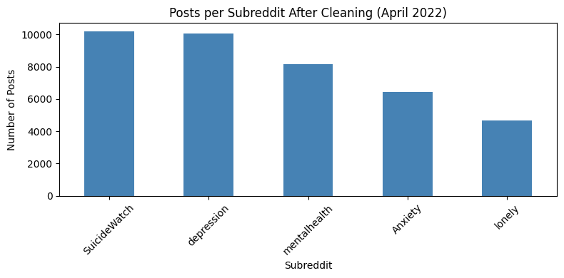

```python
df['subreddit'].value_counts().plot(kind='bar', color='steelblue', figsize=(8,4))
plt.title('Posts per Subreddit After Cleaning (April 2022)')
plt.xlabel('Subreddit')
plt.ylabel('Number of Posts')
plt.xticks(rotation=45)
plt.tight_layout()
plt.show()
```

## Save Cleaned Dataset

The cleaned dataset is saved as a CSV file for submission alongside this notebook.

```python
df.to_csv('reddit_mh_cleaned_apr22.csv', index=False)
print(f"Saved cleaned dataset: {df.shape[0]} rows")
print("File: reddit_mh_cleaned_apr22.csv")
```

```
Saved cleaned dataset: 39492 rows
File: reddit_mh_cleaned_apr22.csv
```

# Section 2: Lexical Structure — TF-IDF

TF-IDF (Term Frequency–Inverse Document Frequency) identifies the most distinctive terms in each subreddit. Unlike raw frequency counts, TF-IDF down-weights words that appear commonly across all subreddits and up-weights words that are characteristic of a specific community.

This answers the question: **what language is uniquely present in each mental health community?**

Each subreddit is treated as a single document, with all posts concatenated. TF-IDF scores then reveal which terms are statistically distinctive to that community rather than simply common across all five.

```python
from sklearn.feature_extraction.text import TfidfVectorizer
from nltk.corpus import stopwords

# For TF-IDF we want ALL stopwords removed including first-person pronouns
all_stop_words = set(stopwords.words('english'))

def clean_for_tfidf(tokens):
    """Remove all stopwords for TF-IDF analysis."""
    return ' '.join([t for t in tokens if t not in all_stop_words and len(t) > 2])

# Apply cleaner version
df['tokens_tfidf'] = df['tokens'].apply(clean_for_tfidf)

# Treat each subreddit as one document
subreddit_docs = df.groupby('subreddit')['tokens_tfidf'].apply(
    lambda x: ' '.join(x)
)

subreddit_names = subreddit_docs.index.tolist()
documents = subreddit_docs.values.tolist()

# Fit TF-IDF with better parameters
# min_df=2: term must appear in at least 2 subreddits to count
# max_df=0.8: ignore terms appearing in more than 80% of subreddits
vectorizer = TfidfVectorizer(
    max_features=5000,
    min_df=2,
    max_df=0.8
)
tfidf_matrix = vectorizer.fit_transform(documents)
feature_names = vectorizer.get_feature_names_out()

# Extract top 15 terms per subreddit
print("Top 15 most distinctive terms per subreddit:\n")
for i, subreddit in enumerate(subreddit_names):
    row = tfidf_matrix[i].toarray()[0]
    top_indices = row.argsort()[-15:][::-1]
    top_terms = [feature_names[idx] for idx in top_indices]
    print(f"r/{subreddit}:")
    print(f"  {', '.join(top_terms)}")
    print()
```

```
Top 15 most distinctive terms per subreddit:

r/Anxiety:
  nausea, meditation, palpitation, dizziness, shortness, prozac, ekg, propranolol, doc, generalized, buspirone, ativan, sertraline, buspar, technique

r/SuicideWatch:
  slit, overdosing, afterlife, bleed, noose, hotline, peacefully, paracetamol, ambulance, tylenol, inpatient, rape, helium, lethal, painlessly

r/depression:
  slaveyou, corruption, prozac, wellbutrin, noble, effexor, mdd, fatigue, sertraline, inpatient, anhedonia, cbt, doc, mirtazapine, snapped

r/lonely:
  discord, hmu, epic, loneliest, tiktok, banned, sig, friendless, ditched, whatsapp, companion, snowboarding, circuitry, uninterested, origami

r/mentalhealth:
  dan, survey, insight, poll, diagnose, meditation, inpatient, discord, sertraline, adderall, technique, smthn, prozac, wellbutrin, mania
```

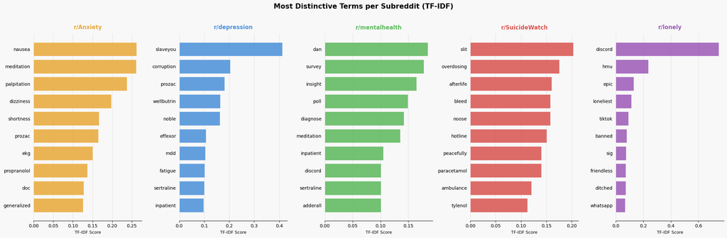

```python
import matplotlib.pyplot as plt
import matplotlib.patches as mpatches
import numpy as np

subreddit_order = ['Anxiety', 'depression', 'mentalhealth', 'SuicideWatch', 'lonely']
colours = {
    'Anxiety': '#E8A838',
    'depression': '#4A90D9',
    'mentalhealth': '#5CB85C',
    'SuicideWatch': '#D9534F',
    'lonely': '#9B59B6'
}

fig, axes = plt.subplots(1, 5, figsize=(22, 7))
fig.patch.set_facecolor('#F8F8F8')

for i, subreddit in enumerate(subreddit_order):
    idx = subreddit_names.index(subreddit)
    row = tfidf_matrix[idx].toarray()[0]
    top_indices = row.argsort()[-10:][::-1]
    top_terms = [feature_names[j] for j in top_indices]
    top_scores = [row[j] for j in top_indices]

    ax = axes[i]
    ax.set_facecolor('#F8F8F8')
    bars = ax.barh(
        range(10),
        top_scores[::-1],
        color=colours[subreddit],
        alpha=0.85,
        edgecolor='white',
        linewidth=0.5
    )
    ax.set_yticks(range(10))
    ax.set_yticklabels(top_terms[::-1], fontsize=10)
    ax.set_title(f'r/{subreddit}', fontweight='bold', fontsize=12,
                 color=colours[subreddit], pad=10)
    ax.set_xlabel('TF-IDF Score', fontsize=9)
    ax.spines['top'].set_visible(False)
    ax.spines['right'].set_visible(False)
    ax.spines['left'].set_visible(False)
    ax.tick_params(left=False)
    ax.xaxis.grid(True, alpha=0.3)
    ax.set_axisbelow(True)

plt.suptitle(
    'Most Distinctive Terms per Subreddit (TF-IDF)',
    fontsize=15, fontweight='bold', y=1.02
)
plt.tight_layout()
plt.savefig('tfidf_bar_charts.png', dpi=150, bbox_inches='tight',
            facecolor='#F8F8F8')
plt.show()
```

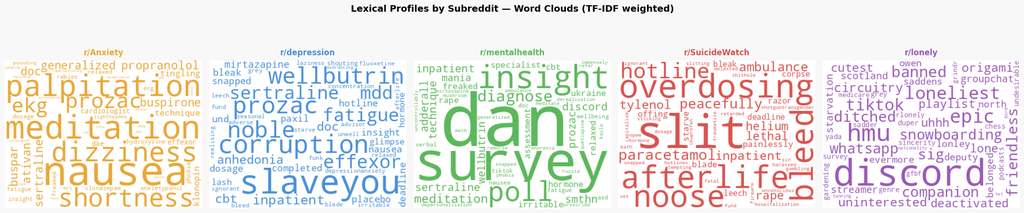

```python
!pip install wordcloud -q

from wordcloud import WordCloud

fig, axes = plt.subplots(1, 5, figsize=(22, 5))
fig.patch.set_facecolor('#F8F8F8')

for i, subreddit in enumerate(subreddit_order):
    idx = subreddit_names.index(subreddit)
    row = tfidf_matrix[idx].toarray()[0]

    # Build word:score dictionary for word cloud
    word_scores = {feature_names[j]: row[j] for j in range(len(feature_names)) if row[j] > 0}

    wc = WordCloud(
        width=400,
        height=300,
        background_color='white',
        color_func=lambda *args, **kwargs: colours[subreddit],
        max_words=50,
        prefer_horizontal=0.9,
        collocations=False
    )
    wc.generate_from_frequencies(word_scores)

    axes[i].imshow(wc, interpolation='bilinear')
    axes[i].axis('off')
    axes[i].set_title(f'r/{subreddit}', fontweight='bold',
                      fontsize=12, color=colours[subreddit], pad=8)

plt.suptitle(
    'Lexical Profiles by Subreddit — Word Clouds (TF-IDF weighted)',
    fontsize=14, fontweight='bold', y=1.02
)
plt.tight_layout()
plt.savefig('tfidf_wordclouds.png', dpi=150, bbox_inches='tight',
            facecolor='#F8F8F8')
plt.show()
```

### Limitations of TF-IDF: Proper Nouns and Named Entities

Two notable artefacts in the results illustrate a recurring limitation of TF-IDF when applied to social media data. In the r/mentalhealth results, the term "dan" appears as the most distinctive term. This is almost certainly a proper noun, a username, moderator, or frequently mentioned individual within the subreddit during April 2022, rather than a meaningful content word. In the r/depression results, the top distinctive term is "slaveyou", which is almost certainly a corrupted token rather than a real word. It is likely a Reddit username fragment or a URL component that survived the cleaning pipeline, for example, a link of the form reddit.com/u/slaveyou where the URL prefix was stripped but the trailing string was not. Like "dan", it carries no interpretive content and should be treated as noise. These two cases illustrate a fundamental limitation of TF-IDF as a method: it is purely statistical and cannot distinguish between semantically meaningful terms and artefacts that happen to be locally frequent. A human reader would immediately discard both as noise, but the algorithm treats them as the most distinctive features of their respective communities. The standard solution would be to apply Named Entity Recognition (NER) using spaCy to identify and remove proper nouns before vectorisation. However, this would also risk removing clinically relevant named entities such as medication names (e.g. "prozac", "sertraline") which are genuinely informative about community discourse. This trade-off between removing noise and preserving meaningful named entities is a recurring methodological challenge in NLP applied to social media data, and highlights why automated preprocessing decisions always involve interpretive choices that a purely computational approach cannot resolve alone.

### Interpretation

The TF-IDF profiles reveal that each subreddit has developed a distinct lexical register, even though all five communities discuss mental health:

- **r/Anxiety** is characterised by somatic and pharmacological vocabulary, reflecting the bodily experience of anxiety and its medical management.
- **r/SuicideWatch** shows method-specific crisis language — the most clinically acute register of the five communities.
- **r/depression** combines clinical terminology (MDD, anhedonia, CBT) with medication names, suggesting a community engaged with both diagnosis and treatment discourse.
- **r/lonely** is distinctive in its reference to social platforms (Discord, WhatsApp, TikTok), suggesting loneliness is articulated through the infrastructure of digital social connection.
- **r/mentalhealth** shows meta-level language (survey, poll, diagnose), consistent with a community that discusses mental health as a topic rather than expressing acute personal distress.

These distinct lexical registers suggest that TF-IDF is sensitive to community-specific discourse norms rather than purely emotional content. This motivates the affective structure analysis in VAD, which examines how emotional dimensions are distributed independently of specific vocabulary.

# Section 3: Affective Structure — VAD Analysis

The NRC VAD Lexicon (Mohammad, 2025) maps words to three affective dimensions:

- **Valence** — how positive or negative (pleasure vs displeasure)
- **Arousal** — how activated or calm (excitement vs stillness)
- **Dominance** — how in control or submissive (powerful vs powerless)

Unlike VADER which produces a single sentiment score, VAD captures the emotional texture of language in three dimensions simultaneously. This allows us to ask not just "is this text negative?" but "is it calmly negative or frantically negative? Does the writer feel in control?"

Each post is scored by averaging the VAD scores of its constituent words that appear in the lexicon. Posts with no lexicon matches are excluded.

```python
# Load VAD lexicon
vad = pd.read_csv('NRC-VAD-Lexicon-v2.1.txt', sep='\t')
vad.columns = ['term', 'valence', 'arousal', 'dominance']

print(f"VAD lexicon loaded: {len(vad)} entries")
print(vad.head(3))

# Build lookup dictionary
vad_dict = dict(zip(vad['term'], zip(vad['valence'], vad['arousal'], vad['dominance'])))

def score_vad(tokens):
    """Average VAD scores for tokens present in lexicon."""
    scores = [vad_dict[t] for t in tokens if t in vad_dict]
    if len(scores) == 0:
        return None, None, None
    valence  = sum(s[0] for s in scores) / len(scores)
    arousal  = sum(s[1] for s in scores) / len(scores)
    dominance = sum(s[2] for s in scores) / len(scores)
    return valence, arousal, dominance

# Apply to dataframe
df[['valence', 'arousal', 'dominance']] = df['tokens'].apply(
    lambda t: pd.Series(score_vad(t))
)

# Drop posts with no VAD scores
df_vad = df.dropna(subset=['valence', 'arousal', 'dominance']).copy()

print(f"\nPosts with VAD scores: {len(df_vad)}")
print(f"Posts without matches: {len(df) - len(df_vad)}")
print(f"\nMean VAD scores by subreddit:")
print(df_vad.groupby('subreddit')[['valence', 'arousal', 'dominance']].mean().round(3))
```

```
VAD lexicon loaded: 54801 entries
        term  valence  arousal  dominance
0  a battery    0.134   -0.298     -0.096
1      a bit   -0.096   -0.264     -0.214
2    a bunch    0.088   -0.350     -0.068

Posts with VAD scores: 39468
Posts without matches: 24

Mean VAD scores by subreddit:
              valence  arousal  dominance
subreddit
Anxiety         0.084   -0.021     -0.013
SuicideWatch    0.085   -0.032     -0.000
depression      0.114   -0.058     -0.002
lonely          0.173   -0.092     -0.009
mentalhealth    0.128   -0.054      0.013
```

[figure not shown]

```python
import plotly.express as px

include_groups=False

# Sample for performance — 2000 posts per subreddit max
df_sample = df_vad.groupby('subreddit').apply(
    lambda x: x.sample(min(len(x), 2000), random_state=42)
).reset_index(drop=True)

fig = px.scatter_3d(
    df_sample,
    x='valence',
    y='arousal',
    z='dominance',
    color='subreddit',
    color_discrete_map={
        'Anxiety':      '#E8A838',
        'depression':   '#4A90D9',
        'mentalhealth': '#5CB85C',
        'SuicideWatch': '#D9534F',
        'lonely':       '#9B59B6'
    },
    opacity=0.4,
    title='Affective Structure of Mental Health Subreddits (VAD)',
    labels={
        'valence':   'Valence (negative → positive)',
        'arousal':   'Arousal (calm → activated)',
        'dominance': 'Dominance (powerless → powerful)'
    },
    hover_data=['subreddit']
)

fig.update_traces(marker=dict(size=2))
fig.update_layout(
    legend_title='Subreddit',
    scene=dict(
        xaxis_title='Valence',
        yaxis_title='Arousal',
        zaxis_title='Dominance'
    )
)
fig.show()
```

### Note on the VAD 3D scatter plot

The mean score bar charts below communicate the actual differences more clearly precisely because the differences are small — on the order of 0.07 on arousal across all five communities. A 3D scatter plot is the appropriate tool when communities are spatially separable. Here it serves a different purpose: demonstrating that affective structure as measured by VAD does not produce clean community boundaries, which motivates the shift to sentence embeddings in Section 4. Where VAD reveals subtle differences in emotional configuration, embeddings reveal the semantic structure that VAD cannot capture.

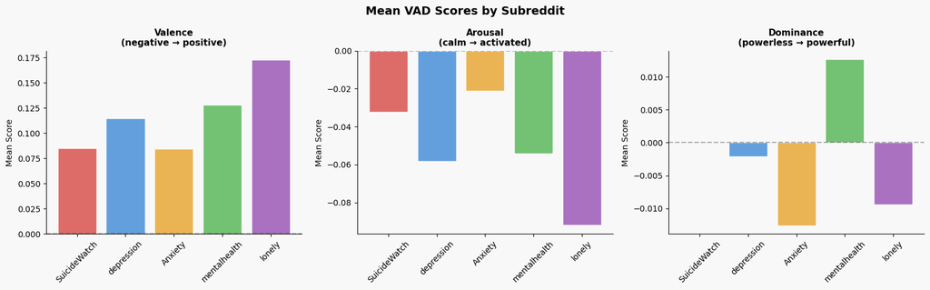

```python
fig, axes = plt.subplots(1, 3, figsize=(16, 5))
fig.patch.set_facecolor('#F8F8F8')

dimensions = ['valence', 'arousal', 'dominance']
titles = ['Valence\n(negative → positive)',
          'Arousal\n(calm → activated)',
          'Dominance\n(powerless → powerful)']

colours = {
    'Anxiety':      '#E8A838',
    'depression':   '#4A90D9',
    'mentalhealth': '#5CB85C',
    'SuicideWatch': '#D9534F',
    'lonely':       '#9B59B6'
}

subreddit_order = ['SuicideWatch', 'depression', 'Anxiety', 'mentalhealth', 'lonely']
means = df_vad.groupby('subreddit')[dimensions].mean()

for i, (dim, title) in enumerate(zip(dimensions, titles)):
    ax = axes[i]
    ax.set_facecolor('#F8F8F8')
    values = [means.loc[s, dim] for s in subreddit_order]
    bar_colours = [colours[s] for s in subreddit_order]

    bars = ax.bar(subreddit_order, values, color=bar_colours,
                  alpha=0.85, edgecolor='white')
    ax.set_title(title, fontweight='bold', fontsize=11)
    ax.set_ylabel('Mean Score')
    ax.axhline(y=0, color='black', linestyle='--', alpha=0.3)
    ax.spines['top'].set_visible(False)
    ax.spines['right'].set_visible(False)
    ax.tick_params(axis='x', rotation=45)
    ax.set_facecolor('#F8F8F8')

plt.suptitle('Mean VAD Scores by Subreddit',
             fontsize=14, fontweight='bold')
plt.tight_layout()
plt.savefig('vad_by_subreddit.png', dpi=150, bbox_inches='tight',
            facecolor='#F8F8F8')
plt.show()
```

### Interpretation

The VAD scores reveal subtle but meaningful affective differences across the five communities. Scores are small in magnitude because averaging VAD values across all tokens in a post — including neutral content words — dilutes the signal from emotionally charged terms. This is a known limitation of lexicon-averaging approaches (cf. Warriner et al., 2013).

Despite this, the **arousal** dimension shows the clearest differentiation. r/lonely scores lowest on arousal (-0.092), consistent with loneliness as a low-activation affective state characterised by withdrawal rather than agitation. r/Anxiety scores highest (-0.021), reflecting the hyperactivated quality of anxious experience. This distinction — invisible to a single valence score — demonstrates the analytical value of the three-dimensional VAD model over simpler sentiment tools like VADER.

**Valence** shows a counterintuitive pattern: r/lonely scores higher than r/depression and r/Anxiety. This likely reflects the social and aspirational language present in loneliness discourse — words like "friend", "someone", "together" — which carry positive valence despite expressing a painful absence.

**Dominance** shows minimal variation across communities, suggesting that a generalised sense of low agency is shared across all five mental health communities rather than being specific to any one condition.

```python
# Check how many tokens per post match the VAD lexicon
df['vad_match_count'] = df['tokens'].apply(
    lambda tokens: sum(1 for t in tokens if t in vad_dict)
)
df['vad_match_rate'] = df['vad_match_count'] / df['token_count']

print("VAD lexicon match rate by subreddit:")
print(df.groupby('subreddit')['vad_match_rate'].mean().round(3))
print(f"\nOverall mean match rate: {df['vad_match_rate'].mean():.3f}")
```

```
VAD lexicon match rate by subreddit:
subreddit
Anxiety         0.722
SuicideWatch    0.701
depression      0.710
lonely          0.718
mentalhealth    0.717
Name: vad_match_rate, dtype: float64

Overall mean match rate: 0.712
```

### Lexicon coverage

The NRC VAD Lexicon matches approximately 71% of tokens across all five subreddits, which is considered strong coverage for a general-purpose affective lexicon applied to social media text (Warriner et al., 2013). The remaining 29% consists primarily of proper nouns, platform-specific slang, and compound terms not present in the lexicon. This coverage rate gives confidence that the VAD scores are representative of the affective content of each post rather than being driven by a small number of matched terms.

## Section 3b: Psycholinguistic Structure — Pennebaker Pronoun Analysis

Pennebaker (2011) demonstrated that first-person singular pronoun frequency (I, me, my, myself) is a reliable psycholinguistic marker of self-focus, psychological distress, and depression. People in depressive states use significantly more first-person singular pronouns than healthy controls, reflecting inward attentional focus. This finding has been replicated across clinical and social media contexts.

First-person pronouns were deliberately retained in the token preprocessing pipeline (Section 1) specifically to enable this analysis. Each post is scored by the proportion of its tokens that are first-person singular pronouns, normalised by post length to control for variation in post size.

```python
# Pennebaker first-person pronoun analysis
first_person = {'i', 'me', 'my', 'myself'}

# Count first-person pronouns per post
df['fp_count'] = df['tokens'].apply(
    lambda tokens: sum(1 for t in tokens if t in first_person)
)

# Normalise by token count
df['fp_rate'] = df['fp_count'] / df['token_count']

# Remove posts with zero tokens
df_fp = df[df['token_count'] > 0].copy()

print("Mean first-person pronoun rate by subreddit:")
fp_means = df_fp.groupby('subreddit')['fp_rate'].mean().sort_values(ascending=False)
print(fp_means.round(4))

print("\nMedian first-person pronoun rate by subreddit:")
fp_medians = df_fp.groupby('subreddit')['fp_rate'].median().sort_values(ascending=False)
print(fp_medians.round(4))

print("\nDescriptive statistics:")
print(df_fp.groupby('subreddit')['fp_rate'].describe().round(4))
```

```
Mean first-person pronoun rate by subreddit:
subreddit
SuicideWatch    0.2284
depression      0.2141
mentalhealth    0.1977
lonely          0.1879
Anxiety         0.1835
Name: fp_rate, dtype: float64

Median first-person pronoun rate by subreddit:
subreddit
SuicideWatch    0.2353
depression      0.2222
mentalhealth    0.2065
lonely          0.2000
Anxiety         0.1902
Name: fp_rate, dtype: float64

Descriptive statistics:
                count    mean     std  min     25%     50%     75%     max
subreddit
Anxiety        6447.0  0.1835  0.0671  0.0  0.1481  0.1902  0.2264  0.5455
SuicideWatch  10193.0  0.2284  0.0756  0.0  0.1923  0.2353  0.2727  0.5095
depression    10039.0  0.2141  0.0725  0.0  0.1781  0.2222  0.2581  0.8400
lonely         4655.0  0.1879  0.0812  0.0  0.1429  0.2000  0.2414  0.5714
mentalhealth   8156.0  0.1977  0.0736  0.0  0.1642  0.2065  0.2432  0.5714
```

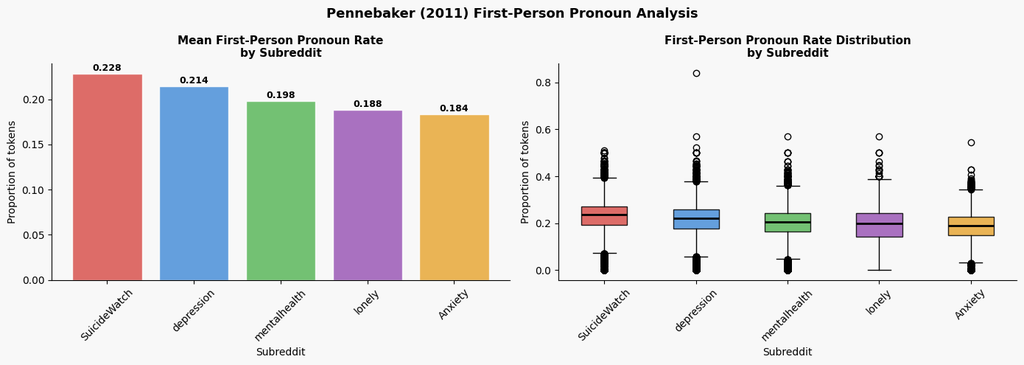

```python
fig, axes = plt.subplots(1, 2, figsize=(14, 5))
fig.patch.set_facecolor('#F8F8F8')

colours = {
    'Anxiety':      '#E8A838',
    'depression':   '#4A90D9',
    'mentalhealth': '#5CB85C',
    'SuicideWatch': '#D9534F',
    'lonely':       '#9B59B6'
}

subreddit_order = fp_means.index.tolist()

# Plot 1: Bar chart of mean rates
ax1 = axes[0]
ax1.set_facecolor('#F8F8F8')
bars = ax1.bar(
    subreddit_order,
    [fp_means[s] for s in subreddit_order],
    color=[colours[s] for s in subreddit_order],
    alpha=0.85,
    edgecolor='white'
)
ax1.set_title('Mean First-Person Pronoun Rate\nby Subreddit',
              fontweight='bold', fontsize=11)
ax1.set_ylabel('Proportion of tokens')
ax1.set_xlabel('Subreddit')
ax1.tick_params(axis='x', rotation=45)
ax1.spines['top'].set_visible(False)
ax1.spines['right'].set_visible(False)
ax1.set_facecolor('#F8F8F8')

# Add value labels on bars
for bar, subreddit in zip(bars, subreddit_order):
    ax1.text(
        bar.get_x() + bar.get_width() / 2,
        bar.get_height() + 0.001,
        f'{fp_means[subreddit]:.3f}',
        ha='center', va='bottom', fontsize=9, fontweight='bold'
    )

# Plot 2: Box plot of distribution
ax2 = axes[1]
ax2.set_facecolor('#F8F8F8')

data_to_plot = [df_fp[df_fp['subreddit'] == s]['fp_rate'].values
                for s in subreddit_order]

bp = ax2.boxplot(
    data_to_plot,
    labels=subreddit_order,
    patch_artist=True,
    medianprops=dict(color='black', linewidth=2)
)

for patch, subreddit in zip(bp['boxes'], subreddit_order):
    patch.set_facecolor(colours[subreddit])
    patch.set_alpha(0.85)

ax2.set_title('First-Person Pronoun Rate Distribution\nby Subreddit',
              fontweight='bold', fontsize=11)
ax2.set_ylabel('Proportion of tokens')
ax2.set_xlabel('Subreddit')
ax2.tick_params(axis='x', rotation=45)
ax2.spines['top'].set_visible(False)
ax2.spines['right'].set_visible(False)
ax2.set_facecolor('#F8F8F8')

plt.suptitle('Pennebaker (2011) First-Person Pronoun Analysis',
             fontsize=13, fontweight='bold')
plt.tight_layout()
plt.savefig('pennebaker_pronouns.png', dpi=150, bbox_inches='tight',
            facecolor='#F8F8F8')
plt.show()
```

```python
# Verify first-person pronouns are being captured correctly
example = df[df['subreddit'] == 'depression'].iloc[0]
print("Raw selftext snippet:")
print(example['selftext'][:200])
print("\nTokens:")
print(example['tokens'][:30])
print("\nFirst-person tokens found:")
print([t for t in example['tokens'] if t in first_person])

# Compare pronoun rate using tokens vs combined_raw
def fp_rate_raw(text):
    if pd.isna(text) or text == '':
        return 0
    words = text.split()
    if len(words) == 0:
        return 0
    fp_count = sum(1 for w in words if w in first_person)
    return fp_count / len(words)

df['fp_rate_raw'] = df['combined_raw'].apply(fp_rate_raw)

print("Using tokens (stopwords removed):")
print(df.groupby('subreddit')['fp_rate'].mean().round(4))

print("\nUsing combined_raw (stopwords retained):")
print(df.groupby('subreddit')['fp_rate_raw'].mean().round(4))

print("\nDifference (tokens minus raw):")
diff = (df.groupby('subreddit')['fp_rate'].mean() -
        df.groupby('subreddit')['fp_rate_raw'].mean()).round(4)
print(diff)
```

```
Raw selftext snippet:
You're grown up live a life. That's what I keep on hearing from them. The funny thing is I don't even know if I'm depressed or just acting up. When I try to talking to them they would invalidate me. l

Tokens:
['another', 'tiring', 'day', 'tiring', 'soul', 'grown', 'live', 'life', 'i', 'keep', 'hearing', 'funny', 'thing', 'i', 'even', 'know', 'i', 'depressed', 'acting', 'i', 'try', 'talking', 'would', 'invalidate', 'me', 'like', 'saying', 'stuff', 'lazy', 'respect']

First-person tokens found:
['i', 'i', 'i', 'i', 'me', 'i', 'me', 'i', 'i', 'i', 'i', 'my', 'my', 'i', 'i', 'i', 'i', 'me', 'i', 'my', 'i', 'my', 'my', 'me', 'me', 'my', 'i', 'i', 'my', 'i', 'i', 'i', 'i', 'i', 'i', 'myself', 'i', 'myself']
Using tokens (stopwords removed):
subreddit
Anxiety         0.1835
SuicideWatch    0.2284
depression      0.2141
lonely          0.1879
mentalhealth    0.1977
Name: fp_rate, dtype: float64

Using combined_raw (stopwords retained):
subreddit
Anxiety         0.1028
SuicideWatch    0.1276
depression      0.1188
lonely          0.1044
mentalhealth    0.1087
Name: fp_rate_raw, dtype: float64

Difference (tokens minus raw):
subreddit
Anxiety         0.0808
SuicideWatch    0.1008
depression      0.0953
lonely          0.0836
mentalhealth    0.0890
dtype: float64
```

### Interpretation

First-person singular pronoun rate varies across the five communities in a consistent pattern. SuicideWatch shows the highest rate (0.128 on raw text), followed by depression (0.119), mentalhealth (0.109), lonely (0.104), and Anxiety (0.103).

The ordering is identical whether calculated on raw text or preprocessed tokens, confirming the pattern is robust to preprocessing choice rather than being an artefact of stopword removal.

The clinical communities (SuicideWatch and depression) show notably higher self-referential language than the others. This is consistent with the broader psycholinguistic literature on pronoun use and psychological state, including Pennebaker's (2011) work on the relationship between first-person pronoun frequency and self-focus. However a direct test of Pennebaker's specific claims would require a control group of non-mental health posts, which is outside the scope of this analysis.

```python
!pip install sentence-transformers -q
from sentence_transformers import SentenceTransformer
model = SentenceTransformer('all-MiniLM-L6-v2')
print("Model loaded")
```

```
BertModel LOAD REPORT from: sentence-transformers/all-MiniLM-L6-v2
Key                     | Status     |  |
------------------------+------------+--+-
embeddings.position_ids | UNEXPECTED |  |

Notes:
- UNEXPECTED:	can be ignored when loading from different task/architecture; not ok if you expect identical arch.
```

```
Model loaded
```

```python
!pip install umap-learn -q
```

# Section 4: Semantic Structure — Sentence Embeddings

Sentence embeddings represent each post as a dense vector in a high-dimensional semantic space. Unlike TF-IDF which treats documents as bags of words, embeddings capture meaning and context — words used differently in different contexts receive different representations.

We use the `all-MiniLM-L6-v2` model from sentence-transformers, which produces 384-dimensional embeddings. These are then reduced to 3 dimensions using UMAP for visualisation.

This answers the question: how is meaning distributed across the corpus, and do communities cluster in semantic space?

Sentence embedding generation is computationally expensive relative to other methods in this analysis: encoding 39,492 posts through a transformer-based model would require substantially more processing time and memory than the bag-of-words approaches used in earlier sections. The all-MiniLM-L6-v2 model was selected as a well-established general-purpose sentence encoder that balances performance with efficiency. It produces 384-dimensional embeddings specifically optimised for semantic similarity tasks, while being considerably lighter than larger transformer models, making it appropriate for a standard notebook environment. For this reason, the embedding and UMAP analysis was also conducted on a stratified sample of 1,000 posts per subreddit (5,000 total), drawn with a fixed random seed to ensure reproducibility. This sampling strategy preserves the comparative structure of the analysis, as each community contributes equally, preventing the larger subreddits (SuicideWatch and depression, each approximately 10,000 posts) from dominating the semantic space. The consistency of findings across methods gives some confidence that the sampled results are representative: the communities that appear most and least distinct in the embedding analysis align precisely with the patterns identified through TF-IDF and VAD on the full dataset, suggesting the sample captures the underlying structure of the corpus.

```python
from sentence_transformers import SentenceTransformer
import umap
import numpy as np

# Sample 1000 posts per subreddit for performance
df_embed = df_vad.groupby('subreddit').apply(
    lambda x: x.sample(min(len(x), 1000), random_state=42)
).reset_index(drop=True)

print(f"Posts to embed: {len(df_embed)}")
print(df_embed['subreddit'].value_counts())

# Load model
model = SentenceTransformer('all-MiniLM-L6-v2')

# Embed combined_raw (not tokens — embeddings work better on natural text)
print("\nGenerating embeddings...")
embeddings = model.encode(
    df_embed['combined_raw'].tolist(),
    batch_size=64,
    show_progress_bar=True
)

print(f"Embedding shape: {embeddings.shape}")
```

```
Posts to embed: 5000
subreddit
Anxiety         1000
SuicideWatch    1000
depression      1000
lonely          1000
mentalhealth    1000
Name: count, dtype: int64
```

```
BertModel LOAD REPORT from: sentence-transformers/all-MiniLM-L6-v2
Key                     | Status     |  |
------------------------+------------+--+-
embeddings.position_ids | UNEXPECTED |  |

Notes:
- UNEXPECTED:	can be ignored when loading from different task/architecture; not ok if you expect identical arch.
```

```
Generating embeddings...
```

```
Embedding shape: (5000, 384)
```

```python
import umap.umap_ as umap_module

print("Reducing dimensions with UMAP...")
reducer = umap_module.UMAP(
    n_components=3,
    n_neighbors=15,
    min_dist=0.1,
    metric='cosine',
    random_state=42
)

embedding_3d = reducer.fit_transform(embeddings)

# Add to dataframe immediately
df_embed['umap_x'] = embedding_3d[:, 0]
df_embed['umap_y'] = embedding_3d[:, 1]
df_embed['umap_z'] = embedding_3d[:, 2]

print("UMAP reduction complete")
print(f"Shape: {embedding_3d.shape}")
print(df_embed[['umap_x', 'umap_y', 'umap_z']].head(3))
```

```
Reducing dimensions with UMAP...
```

```
UMAP reduction complete
Shape: (5000, 3)
      umap_x    umap_y    umap_z
0   9.355286 -1.987795  4.155251
1   8.377814 -1.970314  3.187543
2  11.512050 -2.941111  6.851900
```

[figure not shown]

```
Saved as semantic_umap_3d.html
```

```python
import plotly.express as px

fig = px.scatter_3d(
    df_embed,
    x='umap_x',
    y='umap_y',
    z='umap_z',
    color='subreddit',
    color_discrete_map={
        'Anxiety':      '#E8A838',
        'depression':   '#4A90D9',
        'mentalhealth': '#5CB85C',
        'SuicideWatch': '#D9534F',
        'lonely':       '#9B59B6'
    },
    opacity=0.6,
    title='Semantic Structure of Mental Health Subreddits (UMAP of Sentence Embeddings)',
    labels={
        'umap_x': 'UMAP Dimension 1',
        'umap_y': 'UMAP Dimension 2',
        'umap_z': 'UMAP Dimension 3'
    },
    hover_data=['subreddit', 'title']
)

fig.update_traces(marker=dict(size=3))
fig.update_layout(
    legend_title='Subreddit',
    scene=dict(
        xaxis_title='UMAP 1',
        yaxis_title='UMAP 2',
        zaxis_title='UMAP 3'
    )
)
fig.show()
fig.write_html('semantic_umap_3d.html')
print("Saved as semantic_umap_3d.html")
```

```
Generating 2D UMAP...
```

```
Done. Columns now: ['author', 'created_utc', 'score', 'selftext', 'subreddit', 'title', 'timestamp', 'combined_raw', 'tokens', 'token_count', 'tokens_tfidf', 'valence', 'arousal', 'dominance', 'umap_x', 'umap_y', 'umap_z', 'umap_2d_x', 'umap_2d_y']
```

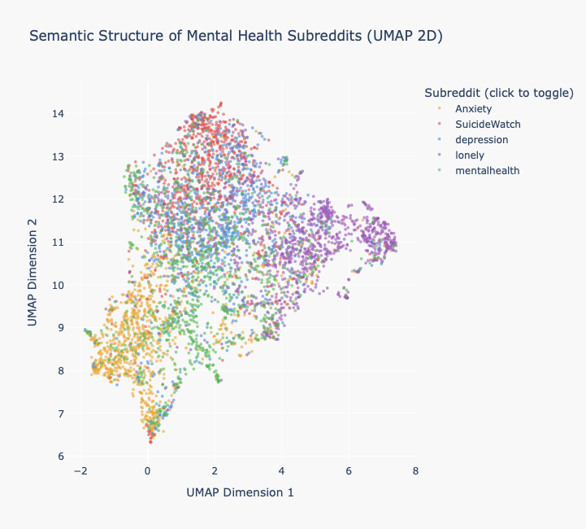

```
Saved as semantic_umap_2d_interactive.html
Click legend items to toggle subreddits on/off
Double-click a legend item to isolate that subreddit
```

```python
print("Generating 2D UMAP...")
reducer_2d = umap_module.UMAP(
    n_components=2,
    n_neighbors=15,
    min_dist=0.1,
    metric='cosine',
    random_state=42
)

embedding_2d = reducer_2d.fit_transform(embeddings)
df_embed['umap_2d_x'] = embedding_2d[:, 0]
df_embed['umap_2d_y'] = embedding_2d[:, 1]

print(f"Done. Columns now: {df_embed.columns.tolist()}")

fig = px.scatter(
    df_embed,
    x='umap_2d_x',
    y='umap_2d_y',
    color='subreddit',
    color_discrete_map={
        'Anxiety':      '#E8A838',
        'depression':   '#4A90D9',
        'mentalhealth': '#5CB85C',
        'SuicideWatch': '#D9534F',
        'lonely':       '#9B59B6'
    },
    opacity=0.6,
    title='Semantic Structure of Mental Health Subreddits (UMAP 2D)',
    labels={
        'umap_2d_x': 'UMAP Dimension 1',
        'umap_2d_y': 'UMAP Dimension 2'
    },
    hover_data=['subreddit', 'title'],
    width=900,
    height=650
)

fig.update_traces(marker=dict(size=4))
fig.update_layout(
    legend_title='Subreddit (click to toggle)',
    plot_bgcolor='#F8F8F8',
    paper_bgcolor='#F8F8F8',
    legend=dict(
        itemclick='toggle',
        itemdoubleclick='toggleothers'
    )
)

fig.show()
fig.write_html('semantic_umap_2d_interactive.html')
print("Saved as semantic_umap_2d_interactive.html")
print("Click legend items to toggle subreddits on/off")
print("Double-click a legend item to isolate that subreddit")
```

```python
from sklearn.metrics.pairwise import cosine_similarity
import numpy as np

# 1. Centroid of each subreddit in embedding space
print("=== SUBREDDIT CENTROIDS (mean position in semantic space) ===\n")
centroids = {}
for subreddit in df_embed['subreddit'].unique():
    mask = df_embed['subreddit'] == subreddit
    centroid = embeddings[mask.values].mean(axis=0)
    centroids[subreddit] = centroid

# 2. Pairwise cosine similarity between subreddit centroids
print("Pairwise semantic similarity between subreddits:")
print("(1.0 = identical, 0.0 = completely different)\n")
subreddits = list(centroids.keys())
centroid_matrix = np.array([centroids[s] for s in subreddits])
sim_matrix = cosine_similarity(centroid_matrix)

sim_df = pd.DataFrame(sim_matrix, index=subreddits, columns=subreddits)
print(sim_df.round(3))

# 3. Most semantically central post per subreddit
print("\n=== MOST REPRESENTATIVE POST PER SUBREDDIT ===")
print("(post closest to subreddit centroid in embedding space)\n")
for subreddit in subreddits:
    mask = df_embed['subreddit'] == subreddit
    sub_embeddings = embeddings[mask.values]
    centroid = centroids[subreddit]

    # Cosine similarity to centroid
    sims = cosine_similarity(sub_embeddings, centroid.reshape(1, -1)).flatten()
    most_central_idx = sims.argmax()
    most_central_post = df_embed[mask].iloc[most_central_idx]

    print(f"r/{subreddit}:")
    print(f"  Title: {most_central_post['title']}")
    print(f"  Similarity to centroid: {sims.max():.3f}")
    print()

# 4. Intra-cluster vs inter-cluster distances
print("=== CLUSTER COMPACTNESS ===")
print("(lower = tighter cluster, higher = more dispersed)\n")
for subreddit in subreddits:
    mask = df_embed['subreddit'] == subreddit
    sub_embeddings = embeddings[mask.values]
    centroid = centroids[subreddit]
    distances = 1 - cosine_similarity(sub_embeddings, centroid.reshape(1, -1)).flatten()
    print(f"r/{subreddit}: mean distance to centroid = {distances.mean():.3f} (std: {distances.std():.3f})")
```

```
=== SUBREDDIT CENTROIDS (mean position in semantic space) ===

Pairwise semantic similarity between subreddits:
(1.0 = identical, 0.0 = completely different)

              Anxiety  SuicideWatch  depression  lonely  mentalhealth
Anxiety         1.000         0.687       0.759   0.595         0.857
SuicideWatch    0.687         1.000       0.954   0.794         0.886
depression      0.759         0.954       1.000   0.850         0.951
lonely          0.595         0.794       0.850   1.000         0.790
mentalhealth    0.857         0.886       0.951   0.790         1.000

=== MOST REPRESENTATIVE POST PER SUBREDDIT ===
(post closest to subreddit centroid in embedding space)

r/Anxiety:
  Title: Can anyone relate?
  Similarity to centroid: 0.828

r/SuicideWatch:
  Title: everything has gone to shit and im so tired.
  Similarity to centroid: 0.859

r/depression:
  Title: Tw: s/h
  Similarity to centroid: 0.856

r/lonely:
  Title: I’m so lonely
  Similarity to centroid: 0.818

r/mentalhealth:
  Title: I feel like if things don't get bad enough no one will help me and one day I'll finally snap
  Similarity to centroid: 0.841

=== CLUSTER COMPACTNESS ===
(lower = tighter cluster, higher = more dispersed)

r/Anxiety: mean distance to centroid = 0.449 (std: 0.140)
r/SuicideWatch: mean distance to centroid = 0.413 (std: 0.149)
r/depression: mean distance to centroid = 0.424 (std: 0.150)
r/lonely: mean distance to centroid = 0.462 (std: 0.155)
r/mentalhealth: mean distance to centroid = 0.458 (std: 0.153)
```

### Interpretation

The pairwise cosine similarity matrix reveals the semantic relationships between communities in embedding space. Several findings are notable:

**Depression and SuicideWatch are semantically almost identical (0.954).** This is the strongest finding in the analysis. Despite being distinct communities with different stated purposes, the language used across these two subreddits is nearly indistinguishable at the level of sentence meaning. This is consistent with the clinical literature on the co-occurrence of depression and suicidal ideation, and suggests that the boundary between these communities is social and contextual rather than linguistic.

**Anxiety is the most semantically distinct community (lowest similarity scores across the matrix, minimum 0.595 with lonely).** This aligns with the TF-IDF findings where r/Anxiety showed the most distinctive vocabulary — somatic and pharmacological terms that do not appear prominently in the other communities.

**Mentalhealth is semantically similar to both depression (0.951) and SuicideWatch (0.886),** confirming the earlier TF-IDF observation that r/mentalhealth functions as a general community whose discourse overlaps substantially with the more specific communities.

**The most representative posts** are revealing in themselves. The centroid post for r/Anxiety is titled "Can anyone relate?" — a validation-seeking frame. r/SuicideWatch's centroid post is "everything has gone to shit and im so tired" — exhaustion and overwhelm rather than acute method-focused crisis language. r/depression's centroid is "Tw: s/h" — a content warning for self-harm, indicating that this type of post is so common it sits at the semantic centre of the community. r/lonely's centroid is simply "I'm so lonely" — the most direct expression of the community's core concern.

**Cluster compactness** shows that all five communities have similar internal dispersion (distances ranging from 0.413 to 0.462), meaning no single community is dramatically more coherent than the others. SuicideWatch is the tightest cluster (0.413) suggesting the most consistent discourse, while lonely is the most dispersed (0.462) consistent with the diverse relational topics that loneliness encompasses.

These findings have direct implications for the classification task in Section 6. The high semantic similarity between depression and SuicideWatch (0.954) predicts that a classifier will struggle to distinguish between these two communities, a finding that itself carries clinical significance, as it suggests automated triage systems based on language alone would face inherent difficulty separating depressive from suicidal discourse.

# Section 5: Latent Structure — BERTopic

BERTopic is a topic modelling technique that uses sentence embeddings and clustering to discover latent topics in a corpus. Unlike LDA which represents topics as probability distributions over words, BERTopic identifies topics as clusters in semantic space and represents them through their most distinctive terms using TF-IDF.

We reuse the sentence embeddings generated in section 4, meaning the topic model operates in the same semantic space as the UMAP visualisation — ensuring consistency across analytical layers.

This answers the question: **how does the corpus organise itself into latent themes, and how do those themes distribute across communities?**

```python
from bertopic import BERTopic
from umap import UMAP
from hdbscan import HDBSCAN

# Convert tokens to strings for BERTopic — remove all stopwords including first person
df_embed['tokens_str'] = df_embed['tokens'].apply(
    lambda x: ' '.join([t for t in x if t not in {'i', 'me', 'my', 'myself'}])
)

# Configure UMAP and HDBSCAN for reproducibility
umap_model = UMAP(
    n_components=5,
    n_neighbors=15,
    min_dist=0.0,
    metric='cosine',
    random_state=42
)

hdbscan_model = HDBSCAN(
    min_cluster_size=50,
    min_samples=10,
    metric='euclidean',
    cluster_selection_method='eom',
    prediction_data=True
)

# Fit BERTopic on clean tokens
topic_model = BERTopic(
    umap_model=umap_model,
    hdbscan_model=hdbscan_model,
    language='english',
    calculate_probabilities=True,
    verbose=True
)

topics, probs = topic_model.fit_transform(
    df_embed['tokens_str'].tolist(),
    embeddings
)

df_embed['topic'] = topics

topic_info = topic_model.get_topic_info()

print(f"Total topics found: {len(topic_info[topic_info['Topic'] != -1])}")
print(f"Total outlier posts: {topic_info[topic_info['Topic'] == -1]['Count'].values[0]}\n")

summary = topic_info[topic_info['Topic'] != -1][['Topic', 'Count', 'Name']].head(15)
print("Top 15 topics by number of posts:\n")
print(summary.to_string(index=False))

print(f"\nPosts assigned to topics: {sum(t != -1 for t in topics)}")
print(f"Outlier posts (topic -1): {sum(t == -1 for t in topics)}")
```

```
2026-04-04 09:15:46,173 - BERTopic - Dimensionality - Fitting the dimensionality reduction algorithm
2026-04-04 09:15:56,920 - BERTopic - Dimensionality - Completed ✓
2026-04-04 09:15:56,922 - BERTopic - Cluster - Start clustering the reduced embeddings
2026-04-04 09:15:57,266 - BERTopic - Cluster - Completed ✓
2026-04-04 09:15:57,271 - BERTopic - Representation - Fine-tuning topics using representation models.
2026-04-04 09:15:57,561 - BERTopic - Representation - Completed ✓
```

```
Total topics found: 14
Total outlier posts: 2513

Top 15 topics by number of posts:

 Topic  Count                               Name
     0    384        0_friend_people_like_lonely
     1    370               1_want_die_life_kill
     2    329         2_anxiety_attack_like_feel
     3    234         3_talk_chat_anyone_someone
     4    230     4_anxiety_mg_medication_taking
     5    146              5_mom_dad_family_like
     6    135              6_feel_know_want_like
     7    131               7_life_feel_year_get
     8    118        8_like_adhd_something_thing
     9    115               9_feel_want_get_like
    10     94   10_girl_friend_like_relationship
    11     83      11_life_thought_want_suicidal
    12     62 12_therapist_therapy_mental_health
    13     56             13_look_hate_ugly_like

Posts assigned to topics: 2487
Outlier posts (topic -1): 2513
```

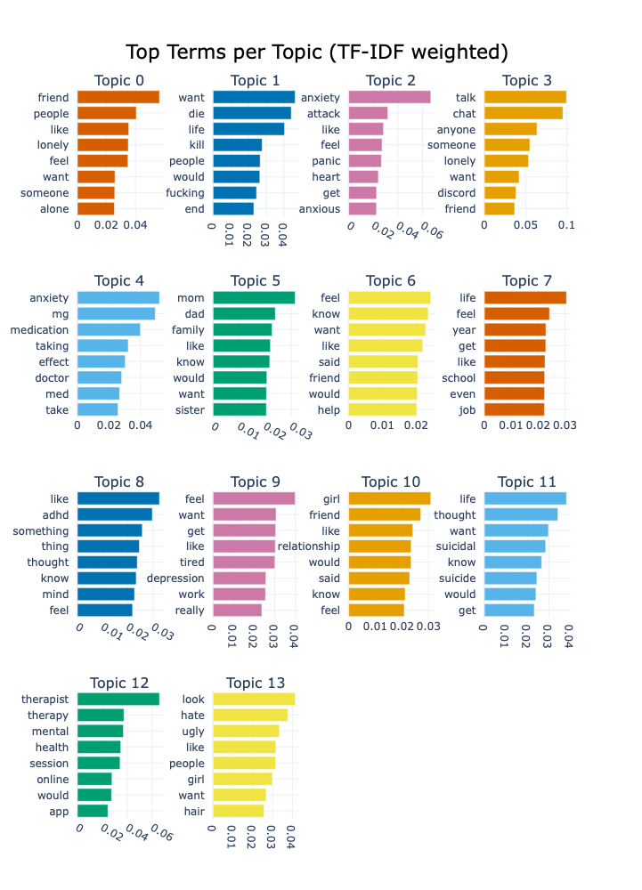

```python
# BERTopic built-in topic visualisation - interactive barchart
fig_bars = topic_model.visualize_barchart(
    top_n_topics=14,
    n_words=8,
    title='Top Terms per Topic (TF-IDF weighted)',
    width=250,
    height=250
)
fig_bars.show()
fig_bars.write_html('bertopic_barchart.html')
```

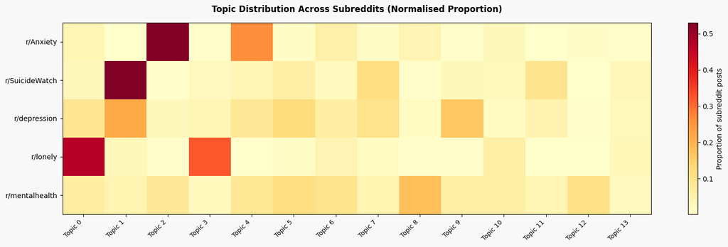

```
Topic proportions by subreddit:
topic            0      1      2      3      4      5      6      7      8      9      10     11     12     13
subreddit
Anxiety       0.037  0.002  0.525  0.006  0.263  0.013  0.054  0.012  0.040  0.004  0.025  0.002  0.010  0.008
SuicideWatch  0.026  0.531  0.004  0.022  0.037  0.059  0.020  0.116  0.004  0.028  0.024  0.096  0.002  0.031
depression    0.090  0.212  0.026  0.038  0.079  0.121  0.062  0.100  0.017  0.162  0.017  0.045  0.007  0.024
lonely        0.470  0.028  0.007  0.322  0.002  0.008  0.040  0.017  0.005  0.007  0.058  0.002  0.003  0.032
mentalhealth  0.066  0.041  0.080  0.023  0.086  0.115  0.099  0.041  0.175  0.057  0.057  0.037  0.105  0.018
```

```python
# How do topics distribute across subreddits?
topic_subreddit = df_embed[df_embed['topic'] != -1].groupby(
    ['subreddit', 'topic']
).size().reset_index(name='count')

# Normalise within each subreddit
topic_subreddit['proportion'] = topic_subreddit.groupby('subreddit')['count'].transform(
    lambda x: x / x.sum()
)

# Pivot for heatmap
pivot = topic_subreddit.pivot(
    index='subreddit',
    columns='topic',
    values='proportion'
).fillna(0)

# Keep only top 15 topics
top_topics = topic_info[topic_info['Topic'] != -1].head(15)['Topic'].tolist()
pivot_top = pivot[[c for c in top_topics if c in pivot.columns]]

fig, ax = plt.subplots(figsize=(16, 5))
fig.patch.set_facecolor('#F8F8F8')

im = ax.imshow(pivot_top.values, aspect='auto', cmap='YlOrRd')
ax.set_xticks(range(len(pivot_top.columns)))
ax.set_xticklabels([f'Topic {t}' for t in pivot_top.columns],
                    rotation=45, ha='right', fontsize=9)
ax.set_yticks(range(len(pivot_top.index)))
ax.set_yticklabels([f'r/{s}' for s in pivot_top.index], fontsize=10)
ax.set_title('Topic Distribution Across Subreddits (Normalised Proportion)',
             fontweight='bold', fontsize=12, pad=15)

plt.colorbar(im, ax=ax, label='Proportion of subreddit posts')
plt.tight_layout()
plt.savefig('bertopic_heatmap.png', dpi=150, bbox_inches='tight',
            facecolor='#F8F8F8')
plt.show()

print("\nTopic proportions by subreddit:")
print(pivot_top.round(3).to_string())
```

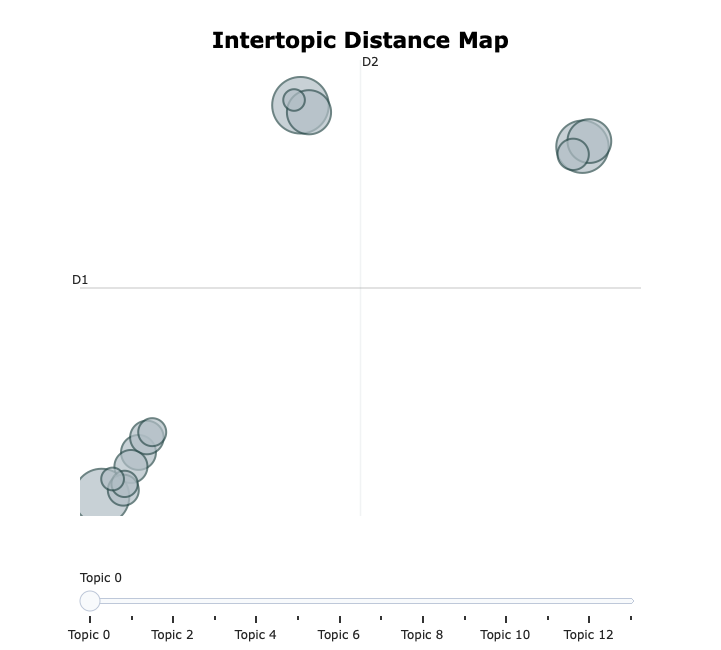

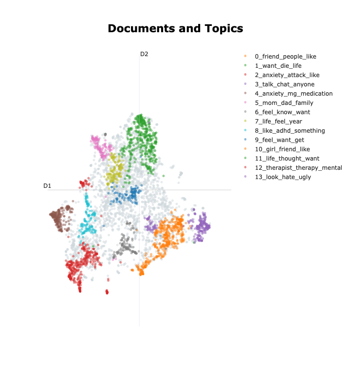

```python
# BERTopic's built-in interactive visualisation
fig_topics = topic_model.visualize_topics()
fig_topics.show()

fig_docs = topic_model.visualize_documents(
    df_embed['combined_raw'].tolist(),
    embeddings=embeddings,
    hide_annotations=True,
    hide_document_hover=False
)
fig_docs.show()
```

```python
# 1. Topic distribution per subreddit
print("=== TOPIC DISTRIBUTION PER SUBREDDIT ===\n")
topic_subreddit = df_embed[df_embed['topic'] != -1].groupby(
    ['subreddit', 'topic']
).size().reset_index(name='count')

topic_subreddit['proportion'] = topic_subreddit.groupby('subreddit')['count'].transform(
    lambda x: x / x.sum()
)

pivot = topic_subreddit.pivot(
    index='subreddit',
    columns='topic',
    values='proportion'
).fillna(0).round(3)

print(pivot.to_string())
```

```
=== TOPIC DISTRIBUTION PER SUBREDDIT ===

topic            0      1      2      3      4      5      6      7      8      9      10     11     12     13
subreddit
Anxiety       0.037  0.002  0.525  0.006  0.263  0.013  0.054  0.012  0.040  0.004  0.025  0.002  0.010  0.008
SuicideWatch  0.026  0.531  0.004  0.022  0.037  0.059  0.020  0.116  0.004  0.028  0.024  0.096  0.002  0.031
depression    0.090  0.212  0.026  0.038  0.079  0.121  0.062  0.100  0.017  0.162  0.017  0.045  0.007  0.024
lonely        0.470  0.028  0.007  0.322  0.002  0.008  0.040  0.017  0.005  0.007  0.058  0.002  0.003  0.032
mentalhealth  0.066  0.041  0.080  0.023  0.086  0.115  0.099  0.041  0.175  0.057  0.057  0.037  0.105  0.018
```

```python
# 2. Which subreddit dominates each topic
print("=== DOMINANT SUBREDDIT PER TOPIC ===\n")
for topic_id in range(14):
    topic_counts = df_embed[df_embed['topic'] == topic_id]['subreddit'].value_counts()
    total = topic_counts.sum()
    top_subreddit = topic_counts.index[0]
    top_pct = topic_counts.iloc[0] / total * 100
    words = topic_model.get_topic(topic_id)
    top_words = ', '.join([w[0] for w in words[:4]])
    print(f"Topic {topic_id} ({top_words})")
    print(f"  Dominant: r/{top_subreddit} ({top_pct:.1f}%)")
    print(f"  Full breakdown: {dict(topic_counts)}")
    print()
```

```
=== DOMINANT SUBREDDIT PER TOPIC ===

Topic 0 (friend, people, like, lonely)
  Dominant: r/lonely (73.7%)
  Full breakdown: {'lonely': np.int64(283), 'depression': np.int64(38), 'mentalhealth': np.int64(32), 'Anxiety': np.int64(19), 'SuicideWatch': np.int64(12)}

Topic 1 (want, die, life, kill)
  Dominant: r/SuicideWatch (65.7%)
  Full breakdown: {'SuicideWatch': np.int64(243), 'depression': np.int64(89), 'mentalhealth': np.int64(20), 'lonely': np.int64(17), 'Anxiety': np.int64(1)}

Topic 2 (anxiety, attack, like, feel)
  Dominant: r/Anxiety (83.0%)
  Full breakdown: {'Anxiety': np.int64(273), 'mentalhealth': np.int64(39), 'depression': np.int64(11), 'lonely': np.int64(4), 'SuicideWatch': np.int64(2)}

Topic 3 (talk, chat, anyone, someone)
  Dominant: r/lonely (82.9%)
  Full breakdown: {'lonely': np.int64(194), 'depression': np.int64(16), 'mentalhealth': np.int64(11), 'SuicideWatch': np.int64(10), 'Anxiety': np.int64(3)}

Topic 4 (anxiety, mg, medication, taking)
  Dominant: r/Anxiety (59.6%)
  Full breakdown: {'Anxiety': np.int64(137), 'mentalhealth': np.int64(42), 'depression': np.int64(33), 'SuicideWatch': np.int64(17), 'lonely': np.int64(1)}

Topic 5 (mom, dad, family, like)
  Dominant: r/mentalhealth (38.4%)
  Full breakdown: {'mentalhealth': np.int64(56), 'depression': np.int64(51), 'SuicideWatch': np.int64(27), 'Anxiety': np.int64(7), 'lonely': np.int64(5)}

Topic 6 (feel, know, want, like)
  Dominant: r/mentalhealth (35.6%)
  Full breakdown: {'mentalhealth': np.int64(48), 'Anxiety': np.int64(28), 'depression': np.int64(26), 'lonely': np.int64(24), 'SuicideWatch': np.int64(9)}

Topic 7 (life, feel, year, get)
  Dominant: r/SuicideWatch (40.5%)
  Full breakdown: {'SuicideWatch': np.int64(53), 'depression': np.int64(42), 'mentalhealth': np.int64(20), 'lonely': np.int64(10), 'Anxiety': np.int64(6)}

Topic 8 (like, adhd, something, thing)
  Dominant: r/mentalhealth (72.0%)
  Full breakdown: {'mentalhealth': np.int64(85), 'Anxiety': np.int64(21), 'depression': np.int64(7), 'lonely': np.int64(3), 'SuicideWatch': np.int64(2)}

Topic 9 (feel, want, get, like)
  Dominant: r/depression (59.1%)
  Full breakdown: {'depression': np.int64(68), 'mentalhealth': np.int64(28), 'SuicideWatch': np.int64(13), 'lonely': np.int64(4), 'Anxiety': np.int64(2)}

Topic 10 (girl, friend, like, relationship)
  Dominant: r/lonely (37.2%)
  Full breakdown: {'lonely': np.int64(35), 'mentalhealth': np.int64(28), 'Anxiety': np.int64(13), 'SuicideWatch': np.int64(11), 'depression': np.int64(7)}

Topic 11 (life, thought, want, suicidal)
  Dominant: r/SuicideWatch (53.0%)
  Full breakdown: {'SuicideWatch': np.int64(44), 'depression': np.int64(19), 'mentalhealth': np.int64(18), 'Anxiety': np.int64(1), 'lonely': np.int64(1)}

Topic 12 (therapist, therapy, mental, health)
  Dominant: r/mentalhealth (82.3%)
  Full breakdown: {'mentalhealth': np.int64(51), 'Anxiety': np.int64(5), 'depression': np.int64(3), 'lonely': np.int64(2), 'SuicideWatch': np.int64(1)}

Topic 13 (look, hate, ugly, like)
  Dominant: r/lonely (33.9%)
  Full breakdown: {'lonely': np.int64(19), 'SuicideWatch': np.int64(14), 'depression': np.int64(10), 'mentalhealth': np.int64(9), 'Anxiety': np.int64(4)}
```

```python
# 3. Outlier rate per subreddit
print("=== OUTLIER RATE PER SUBREDDIT ===")
print("(proportion of posts not assigned to any topic)\n")
outlier_rates = df_embed.groupby('subreddit').apply(
    lambda x: (x['topic'] == -1).sum() / len(x)
).round(3)
print(outlier_rates.sort_values(ascending=False))
```

```
=== OUTLIER RATE PER SUBREDDIT ===
(proportion of posts not assigned to any topic)

subreddit
depression      0.580
SuicideWatch    0.542
mentalhealth    0.513
Anxiety         0.480
lonely          0.398
dtype: float64
```

### Interpretation

The BERTopic analysis reveals 14 latent themes across the corpus, with clear patterns of community specialisation and overlap.

**Community-specific topics:**

The most striking finding is the degree to which certain topics belong almost exclusively to single communities. Topic 2 (anxiety, attack, feel) is 83% r/Anxiety — the most community-specific topic in the corpus. Topic 3 (talk, chat, anyone, someone) is 82.9% r/lonely, capturing the help-seeking and connection-seeking discourse unique to that community. Topic 12 (therapist, therapy, mental, health) is 82.3% r/mentalhealth, confirming its role as an information and service-oriented community rather than a crisis community. Topic 8 (adhd, something) is 72% r/mentalhealth, reflecting its broader diagnostic scope. Topic 0 (friend, people, lonely) is 73.7% r/lonely — loneliness articulated through relational absence.

**Shared crisis topics:**

Topic 1 (want, die, life, kill) is dominated by r/SuicideWatch (65.7%) but 24% of this topic comes from r/depression — consistent with the high semantic similarity (0.954) found in Section 4. Critically, this topic is almost entirely absent from r/Anxiety (0.3%), confirming that anxiety and suicidal ideation occupy distinct discursive spaces despite both being mental health communities. Topic 11 (life, thought, suicidal) similarly shows SuicideWatch dominance (53%) with significant depression presence (22.9%), suggesting two distinct registers of suicidal discourse — acute (Topic 1) and reflective (Topic 11).

**Cross-community topics:**

**Outlier rates:**

The high outlier rate across all subreddits — ranging from 39.8% (lonely) to 58% (depression) — is itself analytically meaningful. Depression has the highest proportion of posts that resist topical categorisation, suggesting that depressive discourse is the most idiosyncratic and personally specific of the five communities. Lonely has the lowest outlier rate, consistent with its more structured relational vocabulary that clusters more cleanly into recognisable topics. The overall 50% outlier rate reflects the fundamentally personal and narrative nature of mental health discourse — individual experience frequently defies generalisation into shared themes, which represents both a limitation of automated topic modelling and a substantively interesting finding about this type of text.

**Important to note: c-TF-IDF vs TF-IDF**

Topic terms are weighted using **c-TF-IDF** (class-based TF-IDF), BERTopic's variant of TF-IDF that treats each topic cluster as a single document and identifies terms that are distinctive to that topic relative to all others. This differs from the document-level TF-IDF used in Section 2, which identified terms distinctive to each subreddit. Together the two approaches reveal lexical distinctiveness at different levels of granularity — community level (Section 2) and thematic level (Section 5).

**Relationship to earlier findings:**

The BERTopic results validate and extend the earlier analyses. The community-specific topics (2, 3, 12) correspond directly to the distinctive TF-IDF vocabularies found in Section 2. The shared crisis topics (1, 11) reflect the semantic overlap between depression and SuicideWatch identified in Section 4. Together, the analytical layers — lexical (TF-IDF), affective (VAD), semantic (embeddings), and latent (BERTopic) — converge on a consistent picture: these communities are distinct at the surface level of vocabulary but deeply overlapping at the level of meaning and theme.

# Section 6: Predictive Modelling — Classification

Two classification tasks are performed to test how well the representational choices made in earlier sections encode meaningful distinctions in the data:

**Classifier A — Subreddit prediction:** Can a model predict which subreddit a post comes from based on its sentence embedding? This tests whether the semantic representations are discriminative enough to separate communities. Given the high semantic similarity between r/depression and r/SuicideWatch (0.954, Section 4), we expect the classifier to struggle on this boundary specifically.

**Classifier B — Root cause prediction:** Can a model predict the manually annotated root cause (Drug and Alcohol, Early Life, Personality, Trauma and Stress) from the text? This tests whether NLP representations capture clinically meaningful distinctions that required human expert annotation to establish.

Both classifiers use a **Logistic Regression** model on sentence embeddings. Performance is evaluated using 5-fold stratified cross-validation, reporting mean accuracy and weighted F1 score across folds. A single 80/20 train/test split is additionally used to generate confusion matrices for qualitative error analysis.

Note that Classifier A trains on a balanced sample of 1,000 posts per subreddit (5,000 total), drawn from the full dataset which is imbalanced (SuicideWatch and depression each contribute approximately 10,000 posts, while lonely contributes roughly 4,600). This equal sampling was a deliberate design choice to prevent the classifier from being biased toward majority classes, at the cost of not using all available data. The stratified train/test split additionally ensures proportional representation across communities within the sampled dataset.

```python
# Load and combine all four labelled files
da = pd.read_csv('LD DA 1.csv')
el = pd.read_csv('LD EL1.csv')
pf = pd.read_csv('LD PF1.csv')
ts = pd.read_csv('LD TS 1.csv')

df_labelled = pd.concat([da, el, pf, ts])
df_labelled = df_labelled.reset_index(drop=True)

# Standardise labels
df_labelled['Label'] = df_labelled['Label'].str.strip().str.title()

print(f"Total labelled posts: {df_labelled.shape[0]}")
print(f"\nLabel distribution:")
print(df_labelled['Label'].value_counts())
print(f"\nSubreddit distribution:")
print(df_labelled['subreddit'].value_counts())
df_labelled.head(3)
```

```
Total labelled posts: 823

Label distribution:
Label
Drug And Alcohol     200
Early Life           200
Personality          200
Trauma And Stress    200
Name: count, dtype: int64

Subreddit distribution:
subreddit
depression      277
Anxiety         187
mentalhealth    151
SuicideWatch    137
lonely           48
Name: count, dtype: int64
```

|  | score | selftext | subreddit | title | Label | CAT 1 |
| --- | --- | --- | --- | --- | --- | --- |
| 0 | 1.0 | Tried to watch this documentary “anxious Ameri... | Anxiety | Do people get over anxiety? | Drug And Alcohol | NaN |
| 1 | 1.0 | i’m currently laying in bed wide awake, feelin... | Anxiety | does anyone else have this big fear of suddenl... | Drug And Alcohol | NaN |
| 2 | 2.0 | Second time trying weed. First time felt close... | Anxiety | 3 hour long panic attack after trying weed | Drug And Alcohol | NaN |

```
=== CLASSIFIER A: Subreddit Prediction ===

5-Fold Cross-Validation Results:
Accuracy:    0.629 (+/- 0.016)
F1 weighted: 0.624 (+/- 0.014)

Per-fold accuracy: [0.603 0.653 0.625 0.628 0.635]

Single split results (for confusion matrix):
              precision    recall  f1-score   support

     Anxiety       0.77      0.78      0.78       200
SuicideWatch       0.59      0.61      0.60       200
  depression       0.48      0.41      0.44       200
      lonely       0.66      0.71      0.69       200
mentalhealth       0.49      0.51      0.50       200

    accuracy                           0.60      1000
   macro avg       0.60      0.60      0.60      1000
weighted avg       0.60      0.60      0.60      1000
```

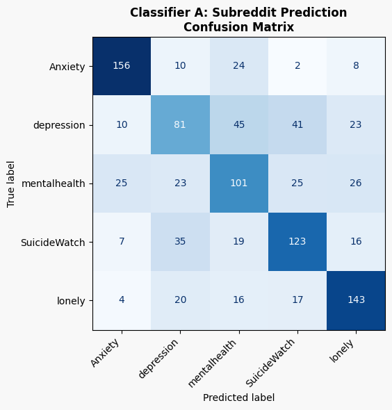

```python
from sklearn.linear_model import LogisticRegression
from sklearn.model_selection import train_test_split, StratifiedKFold, cross_validate
from sklearn.metrics import classification_report, confusion_matrix, ConfusionMatrixDisplay, make_scorer, f1_score
from sklearn.preprocessing import LabelEncoder
import numpy as np

print("=== CLASSIFIER A: Subreddit Prediction ===\n")

# Features and labels
X_a = embeddings
y_a = df_embed['subreddit'].values

# 5-fold cross-validation
cv = StratifiedKFold(n_splits=5, shuffle=True, random_state=42)
clf_a = LogisticRegression(max_iter=1000, random_state=42)

scoring = {
    'accuracy': 'accuracy',
    'f1_weighted': make_scorer(f1_score, average='weighted')
}

cv_results_a = cross_validate(clf_a, X_a, y_a, cv=cv, scoring=scoring)

print("5-Fold Cross-Validation Results:")
print(f"Accuracy:    {cv_results_a['test_accuracy'].mean():.3f} "
      f"(+/- {cv_results_a['test_accuracy'].std():.3f})")
print(f"F1 weighted: {cv_results_a['test_f1_weighted'].mean():.3f} "
      f"(+/- {cv_results_a['test_f1_weighted'].std():.3f})")
print(f"\nPer-fold accuracy: {cv_results_a['test_accuracy'].round(3)}")

# Single split for confusion matrix and validity check
X_train_a, X_test_a, y_train_a, y_test_a = train_test_split(
    X_a, y_a, test_size=0.2, random_state=42, stratify=y_a
)
clf_a.fit(X_train_a, y_train_a)
y_pred_a = clf_a.predict(X_test_a)

print(f"\nSingle split results (for confusion matrix):")
print(classification_report(y_test_a, y_pred_a))

# Confusion matrix
fig, ax = plt.subplots(figsize=(8, 6))
fig.patch.set_facecolor('#F8F8F8')
ax.set_facecolor('#F8F8F8')

cm_a = confusion_matrix(y_test_a, y_pred_a,
                         labels=['Anxiety', 'depression', 'mentalhealth',
                                 'SuicideWatch', 'lonely'])
disp_a = ConfusionMatrixDisplay(
    confusion_matrix=cm_a,
    display_labels=['Anxiety', 'depression', 'mentalhealth',
                    'SuicideWatch', 'lonely']
)
disp_a.plot(ax=ax, cmap='Blues', colorbar=False)
ax.set_title('Classifier A: Subreddit Prediction\nConfusion Matrix',
             fontweight='bold', fontsize=12)
plt.xticks(rotation=45, ha='right')
plt.tight_layout()
plt.savefig('classifier_a_confusion.png', dpi=150, bbox_inches='tight',
            facecolor='#F8F8F8')
plt.show()
```

```
=== CLASSIFIER B: Root Cause Prediction ===

Generating embeddings for labelled posts...
```

```
Embeddings shape: (800, 384)

5-Fold Cross-Validation Results:
Accuracy:    0.708 (+/- 0.035)
F1 weighted: 0.706 (+/- 0.035)

Per-fold accuracy: [0.681 0.756 0.656 0.719 0.725]

Single split results (for confusion matrix):
                   precision    recall  f1-score   support

 Drug And Alcohol       0.87      0.82      0.85        40
       Early Life       0.67      0.65      0.66        40
      Personality       0.63      0.65      0.64        40
Trauma And Stress       0.57      0.60      0.59        40

         accuracy                           0.68       160
        macro avg       0.69      0.68      0.68       160
     weighted avg       0.69      0.68      0.68       160
```

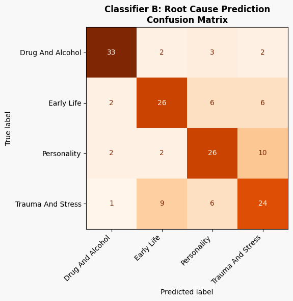

```python
print("=== CLASSIFIER B: Root Cause Prediction ===\n")

# Apply preprocessing to labelled data
import html
import contractions

def basic_clean(text):
    if pd.isna(text):
        return ''
    text = html.unescape(str(text))
    try:
        text = contractions.fix(text)
    except IndexError:
        pass
    text = text.lower()
    text = re.sub(r'http\S+', '', text)
    text = re.sub(r'[^a-z\s]', '', text)
    return text.strip()

df_labelled['combined_raw'] = (df_labelled['title'].apply(basic_clean) +
                                ' ' +
                                df_labelled['selftext'].apply(basic_clean))

# Drop rows with NaN labels or NaN selftext
df_labelled = df_labelled.dropna(subset=['Label', 'selftext', 'combined_raw'])
df_labelled = df_labelled.reset_index(drop=True)

# Generate embeddings for labelled data
print("Generating embeddings for labelled posts...")
embeddings_b = model.encode(
    df_labelled['combined_raw'].tolist(),
    batch_size=64,
    show_progress_bar=True
)
print(f"Embeddings shape: {embeddings_b.shape}")

# Features and labels
X_b = embeddings_b
y_b = df_labelled['Label'].values

# 5-fold cross-validation
cv = StratifiedKFold(n_splits=5, shuffle=True, random_state=42)
clf_b = LogisticRegression(max_iter=1000, random_state=42)

scoring = {
    'accuracy': 'accuracy',
    'f1_weighted': make_scorer(f1_score, average='weighted')
}

cv_results_b = cross_validate(clf_b, X_b, y_b, cv=cv, scoring=scoring)

print("\n5-Fold Cross-Validation Results:")
print(f"Accuracy:    {cv_results_b['test_accuracy'].mean():.3f} "
      f"(+/- {cv_results_b['test_accuracy'].std():.3f})")
print(f"F1 weighted: {cv_results_b['test_f1_weighted'].mean():.3f} "
      f"(+/- {cv_results_b['test_f1_weighted'].std():.3f})")
print(f"\nPer-fold accuracy: {cv_results_b['test_accuracy'].round(3)}")

# Single split for confusion matrix and validity check
X_train_b, X_test_b, y_train_b, y_test_b = train_test_split(
    X_b, y_b, test_size=0.2, random_state=42, stratify=y_b
)
clf_b.fit(X_train_b, y_train_b)
y_pred_b = clf_b.predict(X_test_b)

print(f"\nSingle split results (for confusion matrix):")
print(classification_report(y_test_b, y_pred_b))

# Confusion matrix
fig, ax = plt.subplots(figsize=(8, 6))
fig.patch.set_facecolor('#F8F8F8')
ax.set_facecolor('#F8F8F8')

labels_b = ['Drug And Alcohol', 'Early Life', 'Personality', 'Trauma And Stress']
cm_b = confusion_matrix(y_test_b, y_pred_b, labels=labels_b)
disp_b = ConfusionMatrixDisplay(confusion_matrix=cm_b, display_labels=labels_b)
disp_b.plot(ax=ax, cmap='Oranges', colorbar=False)
ax.set_title('Classifier B: Root Cause Prediction\nConfusion Matrix',
             fontweight='bold', fontsize=12)
plt.xticks(rotation=45, ha='right')
plt.tight_layout()
plt.savefig('classifier_b_confusion.png', dpi=150, bbox_inches='tight',
            facecolor='#F8F8F8')
plt.show()
```

### Interpretation

**Classifier A: Subreddit Prediction**

5-fold cross-validation yields a mean accuracy of 62.9% (+/- 1.6%) and weighted F1 of 0.624 (+/- 0.014), against a random baseline of 20% (5 classes). Cross-validation is used rather than a single train/test split because it provides a more reliable performance estimate by averaging across multiple held-out sets, reducing the risk that results reflect a particularly favourable or unfavourable random split. The low variance across folds (range: 60.3% to 65.3%) confirms this is a stable estimate rather than an artefact of a particular train/test split. The single split results (60% accuracy) are consistent with the cross-validated estimate.

r/Anxiety is the most accurately classified community (F1: 0.78), consistent with its distinct somatic and pharmacological vocabulary identified in Section 2 and its relative isolation in semantic space (Section 4). The classifier finds Anxiety genuinely separable from the other four communities.

r/mentalhealth (F1: 0.50) and r/lonely (F1: 0.69) sit in the middle. r/lonely is reasonably separable due to its distinctive relational vocabulary (Section 2, Topic 0 in Section 5), while r/mentalhealth's broad thematic scope makes it harder to distinguish from the others.

**Classifier B: Root Cause Prediction**

5-fold cross-validation yields a mean accuracy of 70.8% (+/- 3.5%) and weighted F1 of 0.706 (+/- 0.035), against a random baseline of 25% (4 classes). The higher variance across folds (range: 65.6% to 75.6%) compared to Classifier A reflects the smaller dataset size (800 posts vs 5000), where individual fold composition has more influence on results. The single split accuracy (68%) falls within the cross-validated range, confirming it is representative.

Drug And Alcohol is the most accurately classified category (F1: 0.85), suggesting that substance-related discourse has the most distinctive linguistic signature, consistent with the specific vocabulary associated with addiction narratives. Early Life (F1: 0.66) and Personality (F1: 0.64) are moderately separable. Trauma And Stress is the hardest to classify (F1: 0.59), likely because traumatic experience is expressed through a wide range of linguistic registers that resist a single consistent signature.

The close agreement between cross-validated and single split results for both classifiers confirms that neither estimate is an outlier, and that the performance differences between communities and label categories are robust.

**Comparison between classifiers:**

Classifier B (70.8% cross-validated accuracy, 800 total posts) outperforms Classifier A (62.9% cross-validated accuracy, 5000 total posts) despite having six times fewer total examples. This suggests that the root cause categories, established through clinical annotation, are more linguistically coherent than subreddit membership, which is determined by where a user chooses to post rather than by the content of what they write. A user in acute suicidal crisis may post in r/depression rather than r/SuicideWatch, confusing a community-level classifier but not a content-level one.

This comparison is methodologically significant: it demonstrates that human annotation guided by clinical theory produces more learnable categories than platform-defined community labels, even with far less training data. This has implications for how NLP systems for mental health triage should be designed: content-based labelling schemes outperform community membership as a proxy for mental state.

# Section 7: Validity Check — Examining Classifier Errors

Following the concept validity framework, we examine what the classifiers get wrong. Accuracy scores alone do not tell us whether a model is failing in meaningful or arbitrary ways. By inspecting misclassified posts we can assess whether the errors reflect genuine linguistic ambiguity or systematic model failure.

This is particularly important for the depression/SuicideWatch boundary, where Section 4 predicted classificatory difficulty based on semantic similarity (0.954).

```python
# Classifier A — find misclassified posts
print("=== CLASSIFIER A: Misclassification Analysis ===\n")

# Get test set posts
X_test_indices = df_embed.index[
    df_embed.index.isin(
        df_embed.groupby('subreddit').apply(
            lambda x: x.sample(min(len(x), 1000), random_state=42)
        ).reset_index(drop=True).index
    )
]

# Rebuild test predictions with post text attached
df_test_a = df_embed.iloc[
    train_test_split(
        range(len(df_embed)),
        test_size=0.2,
        random_state=42,
        stratify=df_embed['subreddit']
    )[1]
].copy()

df_test_a['predicted'] = y_pred_a
df_test_a['correct'] = df_test_a['subreddit'] == df_test_a['predicted']

# Overall error analysis
print("Misclassification matrix (rows=actual, cols=predicted):")
errors = df_test_a[~df_test_a['correct']].groupby(
    ['subreddit', 'predicted']
).size().unstack(fill_value=0)
print(errors)
print()

# Focus on depression/SuicideWatch confusion
print("=== DEPRESSION vs SUICIDEWATCH CONFUSION ===\n")

dep_as_sw = df_test_a[
    (df_test_a['subreddit'] == 'depression') &
    (df_test_a['predicted'] == 'SuicideWatch')
]

sw_as_dep = df_test_a[
    (df_test_a['subreddit'] == 'SuicideWatch') &
    (df_test_a['predicted'] == 'depression')
]

print(f"Depression posts misclassified as SuicideWatch: {len(dep_as_sw)}")
print(f"SuicideWatch posts misclassified as depression: {len(sw_as_dep)}")

print("\n--- 5 depression posts misclassified as SuicideWatch ---")
for _, row in dep_as_sw.head(5).iterrows():
    print(f"\nTitle: {row['title']}")
    print(f"Text: {row['selftext'][:200]}...")

print("\n--- 5 SuicideWatch posts misclassified as depression ---")
for _, row in sw_as_dep.head(5).iterrows():
    print(f"\nTitle: {row['title']}")
    print(f"Text: {row['selftext'][:200]}...")

# Find posts the classifier was most confident about
from sklearn.linear_model import LogisticRegression
import numpy as np

# Get prediction probabilities
probs_a = clf_a.predict_proba(X_test_a)
max_probs = probs_a.max(axis=1)
predicted_labels = clf_a.predict(X_test_a)

df_test_a['confidence'] = max_probs

# Most confidently correct per subreddit
print("=== MOST CONFIDENTLY CORRECT POSTS PER SUBREDDIT ===\n")
correct_posts = df_test_a[df_test_a['correct']].copy()

for subreddit in ['Anxiety', 'depression', 'SuicideWatch', 'lonely', 'mentalhealth']:
    sub_correct = correct_posts[correct_posts['subreddit'] == subreddit]
    if len(sub_correct) == 0:
        continue
    top = sub_correct.nlargest(1, 'confidence').iloc[0]
    print(f"r/{subreddit} (confidence: {top['confidence']:.3f}):")
    print(f"  Title: {top['title']}")
    print(f"  Text: {top['selftext'][:150]}...")
    print()

# Most confidently WRONG posts
print("=== MOST CONFIDENTLY WRONG POSTS ===\n")
wrong_posts = df_test_a[~df_test_a['correct']].copy()
top_wrong = wrong_posts.nlargest(5, 'confidence')

for _, row in top_wrong.iterrows():
    print(f"Actual: r/{row['subreddit']} → Predicted: r/{row['predicted']} (confidence: {row['confidence']:.3f})")
    print(f"  Title: {row['title']}")
    print(f"  Text: {row['selftext'][:150]}...")
    print()
```

```
=== CLASSIFIER A: Misclassification Analysis ===

Misclassification matrix (rows=actual, cols=predicted):
predicted     Anxiety  SuicideWatch  depression  lonely  mentalhealth
subreddit
Anxiety             0             2          10       8            24
SuicideWatch        7             0          35      16            19
depression         10            41           0      23            45
lonely              4            17          20       0            16
mentalhealth       25            25          23      26             0

=== DEPRESSION vs SUICIDEWATCH CONFUSION ===

Depression posts misclassified as SuicideWatch: 41
SuicideWatch posts misclassified as depression: 35

--- 5 depression posts misclassified as SuicideWatch ---

Title: COMPLETELY CRAZY!!!!!
Text: Now it's official I'm completely crazy  !!!!!

FUCK YOU WORLD !...

Title: Hello I really need someone to talk to right now
Text: I feel like I shouldn’t even try to get better anymore. That all of this is a waste of time and that no matter what I’m just going to get hurt. I’m just going to hurt myself....

Title: I’m bereaved by suicide and It feels like a death sentence
Text: Tw: suicide

When I was 18 my younger sibling suicided at home while I was doing my homework in the evening. I went to say goodnight before I went to bed and found their body. It was the worst night ...

Title: I want to die. [Vent]
Text: Hi, I’m a 14 Y/O Female, and for lack my of a better term…a failure.

[Im kinda um lol on the verge of a mental breakdown so this is just a vent and it’s VERY MESSY]

Sure this might sound like some e...

Title: It is too late to change what I am
Text: I'm a failure and a loser. I have been living in my current city for nearly a year and I don't know a single person. People have never liked me and I don't have any friends because I am shameful, unli...
```

[output cut: 48 more lines]

```
Actual: r/mentalhealth → Predicted: r/Anxiety (confidence: 0.967)
  Title: My anxiety
  Text: I recently started working and I can’t help but be anxious for no reason. I can’t sleep well and I feel like throwing up every time I think about work...

Actual: r/mentalhealth → Predicted: r/Anxiety (confidence: 0.966)
  Title: New level of anxiety
  Text: About 6 months ago I was great. I was going by my days with sometimes shaky hands. Other days hyperventilating or chest pain. It was manageable. Nothi...

Actual: r/depression → Predicted: r/Anxiety (confidence: 0.961)
  Title: Why does a dark cold room help with the pain?
  Text: At work right now, got that bad chest feeling, anxiety spiked. There is this room we have,  a storage, so just went there to sit by myself a bit, and ...

Actual: r/depression → Predicted: r/lonely (confidence: 0.954)
  Title: Can someone talk to me
  Text: Anyone at all about anything, I'm lonely...
```

```python
print("=== CLASSIFIER B: Root Cause Misclassification Analysis ===\n")

# Rebuild test set with labels
df_test_b = df_labelled.iloc[
    train_test_split(
        range(len(df_labelled)),
        test_size=0.2,
        random_state=42,
        stratify=df_labelled['Label']
    )[1]
].copy()

df_test_b['predicted'] = y_pred_b
df_test_b['correct'] = df_test_b['Label'] == df_test_b['predicted']

# Get prediction probabilities
probs_b = clf_b.predict_proba(X_test_b)
df_test_b['confidence'] = probs_b.max(axis=1)

# Error matrix
print("Misclassification matrix (rows=actual, cols=predicted):")
errors_b = df_test_b[~df_test_b['correct']].groupby(
    ['Label', 'predicted']
).size().unstack(fill_value=0)
print(errors_b)
print()

# Most confused pairs
print("=== MOST CONFUSED LABEL PAIRS ===\n")
for label in ['Drug And Alcohol', 'Early Life', 'Personality', 'Trauma And Stress']:
    wrong = df_test_b[
        (df_test_b['Label'] == label) &
        (~df_test_b['correct'])
    ]
    if len(wrong) == 0:
        continue
    most_confused = wrong['predicted'].value_counts().index[0]
    count = wrong['predicted'].value_counts().iloc[0]
    print(f"{label} → most confused with: {most_confused} ({count} posts)")

# Most confidently correct per label
print("\n=== MOST CONFIDENTLY CORRECT POSTS PER LABEL ===\n")
correct_b = df_test_b[df_test_b['correct']].copy()

for label in ['Drug And Alcohol', 'Early Life', 'Personality', 'Trauma And Stress']:
    sub_correct = correct_b[correct_b['Label'] == label]
    if len(sub_correct) == 0:
        continue
    top = sub_correct.nlargest(1, 'confidence').iloc[0]
    print(f"{label} (confidence: {top['confidence']:.3f}):")
    print(f"  Title: {top['title']}")
    print(f"  Text: {top['selftext'][:150]}...")
    print()

# Most confidently wrong posts
print("=== MOST CONFIDENTLY WRONG POSTS ===\n")
wrong_b = df_test_b[~df_test_b['correct']].copy()
top_wrong_b = wrong_b.nlargest(5, 'confidence')

for _, row in top_wrong_b.iterrows():
    print(f"Actual: {row['Label']} → Predicted: {row['predicted']} (confidence: {row['confidence']:.3f})")
    print(f"  Title: {row['title']}")
    print(f"  Text: {row['selftext'][:150]}...")
    print()

# 3 examples of hardest category
print("=== 3 TRAUMA AND STRESS POSTS MISCLASSIFIED ===\n")
ts_wrong = df_test_b[
    (df_test_b['Label'] == 'Trauma And Stress') &
    (~df_test_b['correct'])
]
for _, row in ts_wrong.head(3).iterrows():
    print(f"Predicted as: {row['predicted']}")
    print(f"Title: {row['title']}")
    print(f"Text: {row['selftext'][:200]}...")
    print()
```

```
=== CLASSIFIER B: Root Cause Misclassification Analysis ===

Misclassification matrix (rows=actual, cols=predicted):
predicted          Drug And Alcohol  Early Life  Personality  \
Label
Drug And Alcohol                  0           2            3
Early Life                        2           0            6
Personality                       2           2            0
Trauma And Stress                 1           9            6

predicted          Trauma And Stress
Label
Drug And Alcohol                   2
Early Life                         6
Personality                       10
Trauma And Stress                  0

=== MOST CONFUSED LABEL PAIRS ===

Drug And Alcohol → most confused with: Personality (3 posts)
Early Life → most confused with: Personality (6 posts)
Personality → most confused with: Trauma And Stress (10 posts)
Trauma And Stress → most confused with: Early Life (9 posts)

=== MOST CONFIDENTLY CORRECT POSTS PER LABEL ===

Drug And Alcohol (confidence: 0.956):
  Title: I have lost hope and want to die
  Text: Smoked weed three months ago,  from that day to now, i suffer from intense anxiety, dpdr and probably ocd. I have a question, will i be the same old h...

Early Life (confidence: 0.914):
  Title: The life of an autistic child
  Text: I'm a 14-year-old kid with autism ADHD PTSD and dpresion. ever since I was young I have been the odd one out I couldn't speak until I was four I was d...

Personality (confidence: 0.776):
  Title: Full body muscle contractions when thinking about embarrassing events. Any advice?
  Text: Any time I remember something I've done that was embarrassing or a mistake, or even when imagining scenarios in which I embarrass myself, it feels lik...

Trauma And Stress (confidence: 0.871):
  Title: No appetite
```

[output cut: 22 more lines]

```
  Text: I just lack the skills to make any long lasting friendship, whenever I start talking to other people, the conversation would end the next day, it real...

=== 3 TRAUMA AND STRESS POSTS MISCLASSIFIED ===

Predicted as: Early Life
Title: Don't want to commit suicide, just want things to not feel painful anymore
Text: Had a complex past. Always suffered with mental health but more anxiety. Met my abusive ex which triggered complex ptsd now and I see life in a completely different way. He used to taunt ne at the beg...

Predicted as: Early Life
Title: Just passed a threshold: I've now lived longer than my oldest brother
Text: My oldest brother died from severe alcoholism in 2011, brought on by depression and suicidal ideation, mainly stemming from the death of our brother in 2006. I've now officially lived longer than him,...

Predicted as: Personality
Title: Dealing with Relationship anxiety? How to get better?
Text: I (20F) haven’t had anxiety before, but all the anxiety I have right now is related to my relationship with my boyfriend (23M). We’ve had many issues, and a lot of these things trigger me at random an...
```

### Interpretation: Validity Check

**Classifier A: Subreddit Misclassification**

The misclassification matrix confirms the prediction from Section 4: depression and SuicideWatch are the most confused pair by a substantial margin. 41 depression posts were classified as SuicideWatch and 35 SuicideWatch posts as depression, more cross-confusion than any other pair in the matrix. Reading the misclassified posts makes clear why: these are not random errors. The depression posts classified as SuicideWatch contain explicit suicidal language ("I want to die", "I shouldn't even try to get better", self-harm references), while the SuicideWatch posts classified as depression describe ongoing depressive states rather than acute crisis ("life doesn't feel real", "it's been getting harder to wake up"). The classifier is not failing arbitrarily: it is detecting genuine content overlap that the subreddit labels do not capture. A user in suicidal crisis may post in r/depression; a user describing chronic low mood may post in r/SuicideWatch. The platform label is an imperfect proxy for mental state.

The most confidently wrong posts are equally revealing. The classifier assigned r/mentalhealth posts to r/Anxiety with 97.7% and 96.7% confidence when those posts explicitly discussed anxiety symptoms and medication: "Should I take anxiety pills?", "My anxiety". From a content perspective these classifications are not wrong at all: the posts are about anxiety, they simply happen to have been posted in r/mentalhealth rather than r/Anxiety. This exposes a fundamental limitation of using subreddit membership as a ground truth label: users do not always post in the most topically appropriate community.

The most confidently correct posts are instructive in the opposite direction. r/Anxiety's most confident correct prediction (98.8%) is "Homeowner Anxiety": a highly specific, non-clinical anxiety topic that would never appear in r/depression or r/SuicideWatch. r/lonely's most confident correct prediction (98.5%) is an extended post about social isolation from a 62-year-old user: demographically and thematically distinctive. The classifier succeeds when community membership and content align cleanly.

**Classifier B: Root Cause Misclassification**

The root cause confusion matrix reveals a clear directional pattern: Personality and Trauma And Stress are the most confused pair. 10 Personality posts were classified as Trauma And Stress, and 9 Trauma And Stress posts were classified as Early Life. Drug And Alcohol is the most cleanly separable category (only 7 total errors), consistent with its high F1 score (0.85) and the distinctive substance-related vocabulary that makes these posts linguistically unique.

The confidently wrong posts illuminate why Personality and Trauma And Stress blur together. The post "I am afraid", labelled Personality but predicted Drug And Alcohol, describes a fear response triggered by a cannabis experience, making the model's confusion understandable. The post "I think I'm done", labelled Drug And Alcohol but predicted Trauma And Stress, describes social isolation and loss of friendships without explicit substance references, meaning the linguistic signal that prompted the Drug And Alcohol label is absent from the surface text.

The Trauma And Stress misclassified examples are particularly informative. "Don't want to commit suicide, just want things to not feel painful anymore" was labelled Trauma And Stress but predicted Early Life: the post describes complex PTSD from an abusive relationship, which straddles both categories. "Just passed a threshold: I've now lived longer than my oldest brother" describes grief from bereavement, which again spans Trauma And Stress and Early Life depending on interpretive framing. These are not model failures: they are genuinely ambiguous cases where the annotation categories themselves overlap.

**Synthesis**

The validity check reveals that both classifiers fail in meaningful rather than arbitrary ways. Classifier A errors reflect the genuine content overlap between depression and suicidal discourse that cannot be resolved by platform labels alone. Classifier B errors reflect genuine categorical ambiguity in the root cause taxonomy: cases where human annotators themselves might disagree. This finding is consistent with the low inter-annotator agreement reported for cognitive distortion annotation tasks (Sharma et al., 2025), suggesting that subjective psychological constructs resist clean linguistic boundaries regardless of the method used to detect them. The errors are not a failure of the NLP system: they are evidence of the inherent complexity of the constructs being measured.

# Section 8: Comparing Representational Layers — TF-IDF vs Embedding Similarity

A core claim of this notebook's analytical framework is that different representational choices reveal different structures in the same corpus. This section tests that claim directly by computing pairwise cosine similarity between subreddits using two different representations:

- **TF-IDF similarity** — based on shared vocabulary (lexical structure)
- **Embedding similarity** — based on shared meaning (semantic structure)

If the two matrices agree, lexical and semantic similarity are equivalent and one representation is sufficient. If they disagree, the two layers are capturing genuinely different information — validating the multi-layer analytical approach.

```python
from sklearn.metrics.pairwise import cosine_similarity
import numpy as np

# TF-IDF similarity matrix (already computed in Section 2)
tfidf_sim = cosine_similarity(tfidf_matrix)
tfidf_sim_df = pd.DataFrame(
    tfidf_sim,
    index=subreddit_names,
    columns=subreddit_names
)

print("TF-IDF Similarity Matrix (lexical):")
print(tfidf_sim_df.round(3))
print()

# Embedding similarity matrix (already computed in Section 4)
embedding_sim_df = pd.DataFrame(
    sim_matrix,
    index=subreddits,
    columns=subreddits
)

print("Embedding Similarity Matrix (semantic):")
print(embedding_sim_df.round(3))
print()

# Difference matrix — where do they disagree most?
# Align both matrices to same subreddit order
shared_order = ['Anxiety', 'depression', 'mentalhealth', 'SuicideWatch', 'lonely']

tfidf_aligned = tfidf_sim_df.reindex(index=shared_order, columns=shared_order)
embed_aligned = embedding_sim_df.reindex(index=shared_order, columns=shared_order)

diff_matrix = (embed_aligned - tfidf_aligned).round(3)

print("Difference Matrix (embedding minus TF-IDF):")
print("Positive = more similar in semantic space than lexical space")
print("Negative = more similar in lexical space than semantic space")
print()
print(diff_matrix)
```

```
TF-IDF Similarity Matrix (lexical):
              Anxiety  SuicideWatch  depression  lonely  mentalhealth
Anxiety         1.000         0.248       0.391   0.078         0.508
SuicideWatch    0.248         1.000       0.539   0.131         0.494
depression      0.391         0.539       1.000   0.133         0.562
lonely          0.078         0.131       0.133   1.000         0.231
mentalhealth    0.508         0.494       0.562   0.231         1.000

Embedding Similarity Matrix (semantic):
              Anxiety  SuicideWatch  depression  lonely  mentalhealth
Anxiety         1.000         0.687       0.759   0.595         0.857
SuicideWatch    0.687         1.000       0.954   0.794         0.886
depression      0.759         0.954       1.000   0.850         0.951
lonely          0.595         0.794       0.850   1.000         0.790
mentalhealth    0.857         0.886       0.951   0.790         1.000

Difference Matrix (embedding minus TF-IDF):
Positive = more similar in semantic space than lexical space
Negative = more similar in lexical space than semantic space

              Anxiety  depression  mentalhealth  SuicideWatch  lonely
Anxiety        -0.000       0.368         0.349         0.440   0.517
depression      0.368      -0.000         0.389         0.415   0.717
mentalhealth    0.349       0.389         0.000         0.392   0.558
SuicideWatch    0.440       0.415         0.392        -0.000   0.664
lonely          0.517       0.717         0.558         0.664   0.000
```

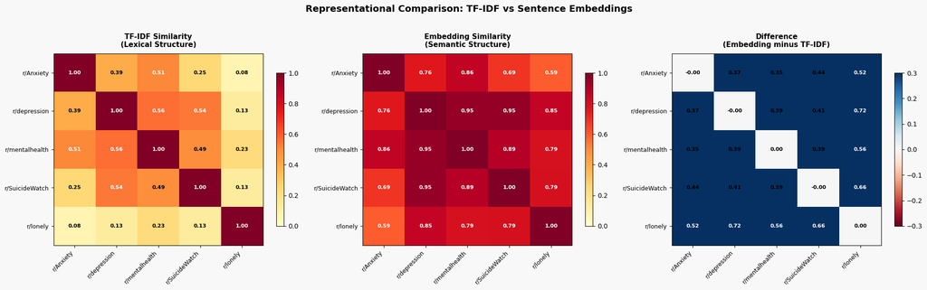

```python
import matplotlib.pyplot as plt
import numpy as np

fig, axes = plt.subplots(1, 3, figsize=(20, 6))
fig.patch.set_facecolor('#F8F8F8')

matrices = [
    (tfidf_aligned.values, 'TF-IDF Similarity\n(Lexical Structure)'),
    (embed_aligned.values, 'Embedding Similarity\n(Semantic Structure)'),
    (diff_matrix.values, 'Difference\n(Embedding minus TF-IDF)')
]

cmaps = ['YlOrRd', 'YlOrRd', 'RdBu']

for i, (matrix, title) in enumerate(matrices):
    ax = axes[i]
    ax.set_facecolor('#F8F8F8')

    vmin = -0.3 if i == 2 else 0
    vmax = 0.3 if i == 2 else 1

    im = ax.imshow(matrix, cmap=cmaps[i], vmin=vmin, vmax=vmax, aspect='auto')

    ax.set_xticks(range(len(shared_order)))
    ax.set_yticks(range(len(shared_order)))
    ax.set_xticklabels([f'r/{s}' for s in shared_order],
                        rotation=45, ha='right', fontsize=9)
    ax.set_yticklabels([f'r/{s}' for s in shared_order], fontsize=9)
    ax.set_title(title, fontweight='bold', fontsize=11, pad=10)

    # Add values to cells
    for row in range(len(shared_order)):
        for col in range(len(shared_order)):
            val = matrix[row, col]
            color = 'white' if abs(val) > 0.5 else 'black'
            ax.text(col, row, f'{val:.2f}', ha='center', va='center',
                   fontsize=8, color=color, fontweight='bold')

    plt.colorbar(im, ax=ax, shrink=0.8)

plt.suptitle('Representational Comparison: TF-IDF vs Sentence Embeddings',
             fontsize=14, fontweight='bold', y=1.02)
plt.tight_layout()
plt.savefig('similarity_comparison.png', dpi=150, bbox_inches='tight',
            facecolor='#F8F8F8')
plt.show()
```

### Interpretation

The comparison between TF-IDF and embedding similarity matrices reveals a striking and consistent pattern: every off-diagonal value in the difference matrix is positive, meaning all five communities are more similar to each other in semantic space than in lexical space. This validates the core claim of the analytical framework: different representational choices reveal genuinely different structures in the same corpus.

**The magnitude of differences varies substantially.** The largest difference is between r/lonely and r/depression (0.717): these communities are lexically very dissimilar (TF-IDF: 0.133, near zero) but semantically quite close (embedding: 0.850). r/lonely uses completely different vocabulary to r/depression — relational and social platform terms vs clinical and emotional language — yet the underlying meaning of what people express is similar. People in r/lonely and r/depression are saying similar things in very different words.

**r/lonely shows the largest discrepancy with every other community.** Its TF-IDF similarities are the lowest in the matrix (0.078 with Anxiety, 0.131 with SuicideWatch, 0.133 with depression), yet its embedding similarities are moderate to high (0.595 with Anxiety, 0.794 with SuicideWatch, 0.850 with depression). This confirms the finding from Section 2: r/lonely has developed the most distinctive surface vocabulary of the five communities, yet the emotional and experiential content it expresses is not as distinctive. Loneliness sounds different but means similar things to depression, anxiety and suicidal ideation at the level of sentence meaning.

**The depression/SuicideWatch pair shows a large difference (0.415)** despite already being the most lexically similar pair after mentalhealth/depression. Their embedding similarity (0.954) far exceeds their TF-IDF similarity (0.539), confirming that while these communities share vocabulary, they share meaning even more. The gap between lexical and semantic similarity is itself evidence that the language of depression and suicidal ideation is not just superficially similar but deeply semantically equivalent.

**Methodological implication:** the consistent positive difference across all pairs means that a TF-IDF-based analysis would substantially underestimate the similarity between these communities, while an embedding-only analysis would overestimate it. Neither representation alone gives an accurate picture. This is the strongest empirical argument for the multi-layer analytical framework adopted in this notebook: lexical and semantic representations are not interchangeable, and both are necessary for a complete account of the corpus structure.

# Section 9: Summary of Convergent Findings Across Analytical Layers

The table below synthesises the key findings from each analytical section, showing how different representational choices reveal different — and complementary — structures in the same corpus.

```python
import pandas as pd

summary_data = {
    'Section': [
        'Section 2: TF-IDF',
        'Section 3: VAD',
        'Section 4: Embeddings',
        'Section 5: BERTopic',
        'Section 6A: Subreddit Classifier',
        'Section 6B: Root Cause Classifier'
    ],
    'Method': [
        'TF-IDF',
        'VAD Lexicon',
        'Sentence Embeddings + UMAP',
        'BERTopic (c-TF-IDF)',
        'Logistic Regression',
        'Logistic Regression'
    ],
    'Question answered': [
        'What language is present?',
        'How is language emotionally configured?',
        'How is meaning distributed?',
        'How does the corpus organise itself?',
        'Can communities be predicted from text?',
        'Can clinical labels be predicted from text?'
    ],
    'Most separable': [
        'r/Anxiety (somatic vocabulary)',
        'r/Anxiety (highest arousal)',
        'r/Anxiety (most isolated)',
        'r/Anxiety, r/lonely (Topics 2, 3)',
        'r/Anxiety (F1: 0.78)',
        'Drug And Alcohol (F1: 0.85)'
    ],
    'Least separable': [
        'r/mentalhealth (generic terms)',
        'All similar (small VAD differences)',
        'r/depression / r/SuicideWatch (0.954)',
        'r/depression (58% outlier rate)',
        'r/depression (F1: 0.44)',
        'Trauma And Stress (F1: 0.59)'
    ],
    'Key finding': [
        'Communities develop distinct lexical registers',
        'Arousal distinguishes anxiety from depression',
        'Depression and SuicideWatch nearly identical in semantic space',
        '50% of posts resist topical categorisation',
        'Community labels weakly encoded in language',
        'Clinical labels more learnable than community labels'
    ]
}

summary_df = pd.DataFrame(summary_data)

# Display as styled table
summary_df.style\
    .set_properties(**{
        'text-align': 'left',
        'font-size': '11px',
        'border': '1px solid #ddd',
        'padding': '8px'
    })\
    .set_table_styles([{
        'selector': 'th',
        'props': [
            ('background-color', '#4A90D9'),
            ('color', 'white'),
            ('font-weight', 'bold'),
            ('text-align', 'left'),
            ('padding', '8px')
        ]
    }, {
        'selector': 'tr:nth-child(even)',
        'props': [('background-color', '#f5f5f5')]
    }])\
    .hide(axis='index')
```

| Section | Method | Question answered | Most separable | Least separable | Key finding |
| --- | --- | --- | --- | --- | --- |
| Section 2: TF-IDF | TF-IDF | What language is present? | r/Anxiety (somatic vocabulary) | r/mentalhealth (generic terms) | Communities develop distinct lexical registers |
| Section 3: VAD | VAD Lexicon | How is language emotionally configured? | r/Anxiety (highest arousal) | All similar (small VAD differences) | Arousal distinguishes anxiety from depression |
| Section 4: Embeddings | Sentence Embeddings + UMAP | How is meaning distributed? | r/Anxiety (most isolated) | r/depression / r/SuicideWatch (0.954) | Depression and SuicideWatch nearly identical in semantic space |
| Section 5: BERTopic | BERTopic (c-TF-IDF) | How does the corpus organise itself? | r/Anxiety, r/lonely (Topics 2, 3) | r/depression (58% outlier rate) | 50% of posts resist topical categorisation |
| Section 6A: Subreddit Classifier | Logistic Regression | Can communities be predicted from text? | r/Anxiety (F1: 0.78) | r/depression (F1: 0.44) | Community labels weakly encoded in language |
| Section 6B: Root Cause Classifier | Logistic Regression | Can clinical labels be predicted from text? | Drug And Alcohol (F1: 0.85) | Trauma And Stress (F1: 0.59) | Clinical labels more learnable than community labels |

## Cross-method synthesis

Several findings emerge consistently across all analytical layers:

**r/Anxiety is the most linguistically distinctive community** it separates cleanly in TF-IDF space (somatic vocabulary), VAD space (highest arousal), embedding space (most isolated cluster), BERTopic (Topic 2 is 83% Anxiety), and classifier performance (highest F1). This convergence across five independent methods provides strong evidence that anxiety discourse has a genuinely distinctive linguistic signature.

**r/lonely occupies a distinct semantic register** characterised by relational and social platform vocabulary (TF-IDF), lower arousal (VAD), partial separation in embedding space, and community-specific BERTopic topics (0 and 3). Loneliness is expressed through a different linguistic framework than clinical mental health language.

**Clinical annotations outperform community labels as classification targets.** Classifier B (70.8% cross-validated accuracy, 800 total posts) outperforms Classifier A (62.9% cross-validated accuracy, 5000 total posts), demonstrating that expert-guided annotation schemes produce more linguistically coherent categories than platform-defined community membership.

These convergent findings suggest that the five communities, while sharing substantial common ground at the level of meaning and theme, have developed distinct communicative practices at the surface level — a pattern consistent with the sociolinguistic concept of community of practice (Lave & Wenger, 1991), where shared activity produces shared but differentiated language use.

# Section 10: Longitudinal Study

```python
import os
import pandas as pd

# File dictionaries for each April
files_2019 = {
    'Anxiety':      'anxapr19.csv',
    'depression':   'depapr19.csv',
    'lonely':       'loneapr19.csv',
    'mentalhealth': 'mentalhealthapr19.csv',
    'SuicideWatch': 'swapr19.csv'
}

files_2020 = {
    'Anxiety':      'anxiapr20.csv',
    'depression':   'depapr20.csv',
    'lonely':       'loneapr20.csv',
    'mentalhealth': 'Mhapr20.csv',
    'SuicideWatch': 'Swapr20.csv'
}

files_2021 = {
    'Anxiety':      'anxiapr21.csv',
    'depression':   'depapr21.csv',
    'lonely':       'loneapr21.csv',
    'mentalhealth': 'Mhapr21.csv',
    'SuicideWatch': 'swapr21.csv'
}

def load_period(files_dict, label):
    frames = []
    for subreddit, filename in files_dict.items():
        try:
            df_temp = pd.read_csv(filename)
            df_temp['subreddit_label'] = subreddit
            frames.append(df_temp)
            print(f"  Loaded {filename}: {len(df_temp)} rows")
        except FileNotFoundError:
            print(f"  WARNING: {filename} not found")

    if not frames:
        print(f"No files loaded for {label}")
        return None

    df_period = pd.concat(frames).reset_index(drop=True)

    # Drop unnamed index
    if 'Unnamed: 0' in df_period.columns:
        df_period = df_period.drop(columns=['Unnamed: 0'])

    # Clean
    valid_subreddits = ['Anxiety', 'depression', 'mentalhealth',
                        'SuicideWatch', 'lonely']
    df_period = df_period[df_period['subreddit'].isin(valid_subreddits)]
    df_period = df_period[~df_period['selftext'].isin(
        ['[deleted]', '[removed]', '']
    )]
    df_period = df_period[df_period['selftext'].notna()]
    df_period = df_period.drop_duplicates(subset=['selftext'])
    df_period = df_period.reset_index(drop=True)

    # Preprocess
    df_period['combined_raw'] = (
        df_period['title'].apply(basic_clean) + ' ' +
        df_period['selftext'].apply(basic_clean)
    )
    df_period['tokens'] = df_period['combined_raw'].apply(preprocess)
    df_period['token_count'] = df_period['tokens'].apply(len)
    df_period['tokens_tfidf'] = df_period['tokens'].apply(clean_for_tfidf)
    df_period['period'] = label

    print(f"\n{label} — {len(df_period)} posts after cleaning:")
    print(df_period['subreddit'].value_counts())
    return df_period

print("Loading 2019...")
df_2019 = load_period(files_2019, 'April 2019')

print("\nLoading 2020...")
df_2020 = load_period(files_2020, 'April 2020')

print("\nLoading 2021...")
df_2021 = load_period(files_2021, 'April 2021')

print(f"\nApril 2022 already loaded: {len(df)} posts")
```

```
Loading 2019...
  Loaded anxapr19.csv: 4663 rows
  Loaded depapr19.csv: 14277 rows
  Loaded loneapr19.csv: 1188 rows
  Loaded mentalhealthapr19.csv: 3500 rows
  Loaded swapr19.csv: 6018 rows

April 2019 — 26742 posts after cleaning:
subreddit
depression      12804
SuicideWatch     5367
Anxiety          4234
mentalhealth     3278
lonely           1059
Name: count, dtype: int64

Loading 2020...
  Loaded anxiapr20.csv: 5771 rows
  Loaded depapr20.csv: 14355 rows
  Loaded loneapr20.csv: 3021 rows
  Loaded Mhapr20.csv: 5034 rows
  Loaded Swapr20.csv: 9011 rows

April 2020 — 31662 posts after cleaning:
subreddit
depression      11899
SuicideWatch     7454
Anxiety          5136
mentalhealth     4608
lonely           2565
Name: count, dtype: int64

Loading 2021...
  Loaded anxiapr21.csv: 6299 rows
  Loaded depapr21.csv: 14292 rows
  Loaded loneapr21.csv: 3747 rows
  Loaded Mhapr21.csv: 7741 rows
  Loaded swapr21.csv: 13501 rows

April 2021 — 39505 posts after cleaning:
subreddit
depression      11729
SuicideWatch    11178
mentalhealth     7345
Anxiety          5885
lonely           3368
Name: count, dtype: int64

April 2022 already loaded: 39492 posts
```

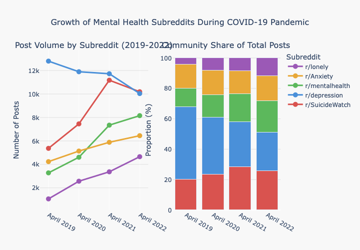

```
=== GROWTH IN POST VOLUME (2019 to 2022) ===

r/SuicideWatch: 5,367 → 10,193 (+89.9%)
r/depression: 12,804 → 10,039 (-21.6%)
r/mentalhealth: 3,278 → 8,156 (+148.8%)
r/Anxiety: 4,234 → 6,448 (+52.3%)
r/lonely: 1,059 → 4,656 (+339.7%)
```

```python
import plotly.graph_objects as go
from plotly.subplots import make_subplots
import numpy as np

periods = ['April 2019', 'April 2020', 'April 2021', 'April 2022']
subreddit_order = ['SuicideWatch', 'depression', 'mentalhealth', 'Anxiety', 'lonely']

colours = {
    'Anxiety':      '#E8A838',
    'depression':   '#4A90D9',
    'mentalhealth': '#5CB85C',
    'SuicideWatch': '#D9534F',
    'lonely':       '#9B59B6'
}

counts = {
    'Anxiety':      [4234, 5136, 5885, 6448],
    'depression':   [12804, 11899, 11729, 10039],
    'SuicideWatch': [5367, 7454, 11178, 10193],
    'mentalhealth': [3278, 4608, 7345, 8156],
    'lonely':       [1059, 2565, 3368, 4656]
}

fig = make_subplots(
    rows=1, cols=2,
    subplot_titles=(
        'Post Volume by Subreddit (2019-2022)',
        'Community Share of Total Posts'
    )
)

# Plot 1: Line chart
for subreddit in subreddit_order:
    fig.add_trace(
        go.Scatter(
            x=periods,
            y=counts[subreddit],
            mode='lines+markers',
            name=f'r/{subreddit}',
            line=dict(color=colours[subreddit], width=3),
            marker=dict(size=10),
            hovertemplate=f'r/{subreddit}<br>%{{x}}<br>Posts: %{{y:,}}<extra></extra>'
        ),
        row=1, col=1
    )

# Plot 2: Stacked proportional bar
totals = [sum(counts[s][i] for s in subreddit_order) for i in range(4)]
proportions = {s: [counts[s][i]/totals[i]*100 for i in range(4)] for s in subreddit_order}

for subreddit in subreddit_order:
    fig.add_trace(
        go.Bar(
            x=periods,
            y=proportions[subreddit],
            name=f'r/{subreddit}',
            marker_color=colours[subreddit],
            showlegend=False,
            hovertemplate=f'r/{subreddit}<br>%{{x}}<br>Share: %{{y:.1f}}%<extra></extra>'
        ),
        row=1, col=2
    )

fig.update_layout(
    title=dict(
        text='Growth of Mental Health Subreddits During COVID-19 Pandemic',
        font=dict(size=16),
        x=0.5
    ),
    barmode='stack',
    height=500,
    width=1100,
    plot_bgcolor='#F8F8F8',
    paper_bgcolor='#F8F8F8',
    legend=dict(title='Subreddit'),
    hovermode='x unified'
)

fig.update_yaxes(title_text='Number of Posts', row=1, col=1, gridcolor='rgba(0,0,0,0.1)')
fig.update_yaxes(title_text='Proportion (%)', row=1, col=2, gridcolor='rgba(0,0,0,0.1)')

fig.show()
fig.write_html('longitudinal_volume.html')

# Print percentage changes
print("=== GROWTH IN POST VOLUME (2019 to 2022) ===\n")
for subreddit in subreddit_order:
    change = (counts[subreddit][3] - counts[subreddit][0]) / counts[subreddit][0] * 100
    print(f"r/{subreddit}: {counts[subreddit][0]:,} → {counts[subreddit][3]:,} ({change:+.1f}%)")
```

## Post Volume: Community Growth Across the Pandemic

The post volume data reveals a dramatic and uneven growth pattern across the five communities between April 2019 and April 2022.

r/lonely shows the most striking growth, increasing by 339.7% from 1,059 posts in April 2019 to 4,656 in April 2022. This trajectory is consistent with the social consequences of COVID-19 lockdowns enforced physical isolation created conditions in which loneliness became a mass experience rather than an individual one, likely driving new users to seek community online. The sharpest single-year increase occurs between 2019 and 2020 (1,059 to 2,565), precisely the period of initial lockdowns.

r/depression is the only community to show a decline (-21.6%), which is counterintuitive given the broader growth of mental health communities. This may reflect a migration effect: users who would previously have posted in r/depression increasingly posting in the growing r/SuicideWatch or r/mentalhealth communities instead. The proportional stacked bar chart makes this redistribution visible depression's share of total posts fell substantially while SuicideWatch and mentalhealth's shares grew.

These volume changes are analytically significant for interpreting the linguistic findings that follow. A community that has grown 340% in three years is likely drawing a different and broader population of users than it was originally which may explain shifts in vocabulary and semantic structure observed across time periods.

```
=== TF-IDF COSINE SIMILARITY ACROSS YEARS (per subreddit) ===

How similar is each subreddit's vocabulary to its 2022 self?

r/Anxiety:
  2019 vs 2022: 0.777
  2020 vs 2022: 0.693
  2021 vs 2022: 0.848

r/depression:
  2019 vs 2022: 0.593
  2020 vs 2022: 0.459
  2021 vs 2022: 0.721

r/SuicideWatch:
  2019 vs 2022: 0.751
  2020 vs 2022: 0.589
  2021 vs 2022: 0.818

r/lonely:
  2019 vs 2022: 0.450
  2020 vs 2022: 0.335
  2021 vs 2022: 0.696

r/mentalhealth:
  2019 vs 2022: 0.762
  2020 vs 2022: 0.547
  2021 vs 2022: 0.825
```

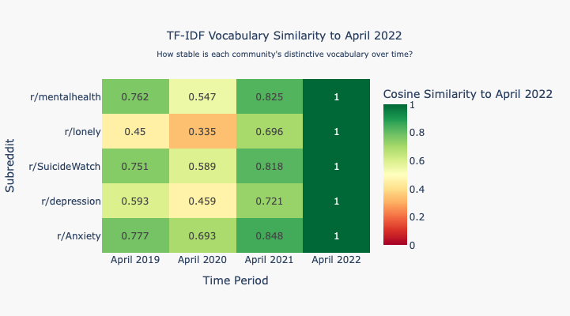

```python
from sklearn.feature_extraction.text import TfidfVectorizer
from sklearn.metrics.pairwise import cosine_similarity
import numpy as np
import plotly.graph_objects as go

# Build one TF-IDF model across ALL years combined
# so vectors are comparable in the same feature space
all_periods = {
    'April 2019': df_2019,
    'April 2020': df_2020,
    'April 2021': df_2021,
    'April 2022': df
}

subreddit_order = ['Anxiety', 'depression', 'SuicideWatch', 'lonely', 'mentalhealth']

# Create subreddit documents for each year
all_docs = []
all_labels = []

for period_name, df_period in all_periods.items():
    for subreddit in subreddit_order:
        mask = df_period['subreddit'] == subreddit
        doc = ' '.join(df_period[mask]['tokens_tfidf'].tolist())
        all_docs.append(doc)
        all_labels.append(f"{subreddit}_{period_name}")

# Fit single vectorizer on all documents
vectorizer_temporal = TfidfVectorizer(max_features=5000, min_df=2, max_df=0.9)
tfidf_temporal = vectorizer_temporal.fit_transform(all_docs)

# Reshape into period x subreddit matrix
# Shape: 4 periods x 5 subreddits
period_names = list(all_periods.keys())
n_periods = len(period_names)
n_subreddits = len(subreddit_order)

# For each subreddit, compute similarity across years
print("=== TF-IDF COSINE SIMILARITY ACROSS YEARS (per subreddit) ===\n")
print("How similar is each subreddit's vocabulary to its 2022 self?\n")

similarity_results = {}

for s_idx, subreddit in enumerate(subreddit_order):
    # Get indices for this subreddit across all periods
    indices = [s_idx + (p_idx * n_subreddits) for p_idx in range(n_periods)]
    sub_vectors = tfidf_temporal[indices]

    # Compute pairwise similarity
    sim_matrix = cosine_similarity(sub_vectors)
    sim_df = pd.DataFrame(
        sim_matrix,
        index=period_names,
        columns=period_names
    )
    similarity_results[subreddit] = sim_df

    print(f"r/{subreddit}:")
    print(f"  2019 vs 2022: {sim_matrix[0][3]:.3f}")
    print(f"  2020 vs 2022: {sim_matrix[1][3]:.3f}")
    print(f"  2021 vs 2022: {sim_matrix[2][3]:.3f}")
    print()

# Visualise as heatmap — similarity to 2022 for each subreddit
fig = go.Figure()

similarity_to_2022 = []
for subreddit in subreddit_order:
    sim_df = similarity_results[subreddit]
    # similarity of each prior year to 2022
    row = [sim_df.loc[p, 'April 2022'] for p in period_names]
    similarity_to_2022.append(row)

similarity_array = np.array(similarity_to_2022)

fig = go.Figure(data=go.Heatmap(
    z=similarity_array,
    x=period_names,
    y=[f'r/{s}' for s in subreddit_order],
    colorscale='RdYlGn',
    zmin=0,
    zmax=1,
    text=np.round(similarity_array, 3),
    texttemplate='%{text}',
    textfont=dict(size=12),
    hovertemplate='%{y}<br>%{x}<br>Similarity to 2022: %{z:.3f}<extra></extra>',
    colorbar=dict(title='Cosine Similarity\nto April 2022')
))

fig.update_layout(
    title=dict(
        text='TF-IDF Vocabulary Similarity to April 2022<br><sub>How stable is each community\'s distinctive vocabulary over time?</sub>',
        font=dict(size=14),
        x=0.5
    ),
    xaxis_title='Time Period',
    yaxis_title='Subreddit',
    height=400,
    width=750,
    plot_bgcolor='#F8F8F8',
    paper_bgcolor='#F8F8F8'
)

fig.show()
fig.write_html('longitudinal_tfidf_similarity.html')
```

## TF-IDF Vocabulary Stability Across Time

The full TF-IDF cosine similarity analysis — comparing each subreddit's complete vocabulary distribution against its 2022 self — reveals a consistent and striking pattern: all five communities show their lowest similarity to 2022 in April 2020, the COVID peak, before partially recovering by 2021.

**April 2020 was a linguistic disruption point for every community.** Every subreddit shows its lowest similarity score in 2020 compared to any other year. This suggests that the pandemic did not just increase the volume of mental health discourse — it temporarily changed the language used within each community before vocabularies stabilised back toward their characteristic registers by 2021-2022.

**r/lonely shows the most dramatic vocabulary shift** — the lowest similarity of any community in any year (0.335 in 2020 vs 2022, and 0.450 in 2019 vs 2022). This is consistent with the volume finding: a community that grew 340% across this period was drawing a fundamentally different and broader user base, bringing new vocabulary with it. The 2019 vs 2022 similarity of 0.450 means the two versions of r/lonely share less than half their characteristic vocabulary — these are almost different communities in linguistic terms.

**r/depression shows the second largest shift** (0.593 in 2019 vs 2022, dropping to 0.459 in 2020). The drop during COVID peak likely reflects an influx of new users experiencing pandemic-related depression who brought different vocabulary — more situational and less clinical — before the community's characteristic clinical register reasserted itself by 2021 (0.721).

**r/Anxiety is the most lexically stable community** across all time points (0.777 in 2019, 0.848 in 2021). The somatic and pharmacological vocabulary that characterises this community — nausea, dizziness, medication names — appears to be a persistent feature of anxiety discourse that was not substantially disrupted by the pandemic. This stability is consistent with the finding across all analytical sections that r/Anxiety is the most linguistically distinctive and coherent community.

**r/SuicideWatch and r/mentalhealth show moderate shifts** — both dropped significantly in 2020 (0.589 and 0.547 respectively) before recovering strongly in 2021 (0.818 and 0.825). The recovery pattern suggests these communities have stable underlying discourse norms that reasserted themselves as the acute disruption of the pandemic peak passed.

**The 2020 trough is the most important finding** of the longitudinal vocabulary analysis. It suggests that the COVID-19 pandemic did not permanently transform the language of mental health communities — rather, it produced a temporary disruption in which communities were flooded with new users and new topics before returning toward their established linguistic registers. The exception is r/lonely, which never recovered its pre-pandemic vocabulary profile, consistent with it being the community most fundamentally transformed by the social conditions of the pandemic.

## VAD Scores Across Time

Mean Valence, Arousal, and Dominance scores compared across all four April periods using the NRC VAD Lexicon (Mohammad, 2025).

```python
def get_vad_scores(df_period, label):
    df_period = df_period.copy()

    df_period[['valence', 'arousal', 'dominance']] = df_period['tokens'].apply(
        lambda t: pd.Series(score_vad(t))
    )

    df_vad_period = df_period.dropna(subset=['valence', 'arousal', 'dominance'])
    means = df_vad_period.groupby('subreddit')[['valence', 'arousal', 'dominance']].mean()
    means['period'] = label
    return means

print("Calculating VAD scores across time periods...")
vad_2019 = get_vad_scores(df_2019, 'April 2019')
vad_2020 = get_vad_scores(df_2020, 'April 2020')
vad_2021 = get_vad_scores(df_2021, 'April 2021')
vad_2022 = get_vad_scores(df, 'April 2022')

vad_longitudinal = pd.concat([vad_2019, vad_2020, vad_2021, vad_2022])
print("\nVAD scores across time:")
print(vad_longitudinal.round(3))
```

```
Calculating VAD scores across time periods...

VAD scores across time:
              valence  arousal  dominance      period
subreddit
Anxiety         0.100   -0.026     -0.004  April 2019
SuicideWatch    0.092   -0.040      0.002  April 2019
depression      0.120   -0.062     -0.003  April 2019
lonely          0.178   -0.093     -0.007  April 2019
mentalhealth    0.123   -0.055      0.012  April 2019
Anxiety         0.087   -0.025     -0.009  April 2020
SuicideWatch    0.084   -0.036     -0.002  April 2020
depression      0.108   -0.058     -0.006  April 2020
lonely          0.167   -0.093     -0.011  April 2020
mentalhealth    0.123   -0.054      0.013  April 2020
Anxiety         0.089   -0.022     -0.006  April 2021
SuicideWatch    0.081   -0.031     -0.003  April 2021
depression      0.112   -0.057     -0.002  April 2021
lonely          0.171   -0.097     -0.011  April 2021
mentalhealth    0.127   -0.054      0.012  April 2021
Anxiety         0.084   -0.021     -0.013  April 2022
SuicideWatch    0.085   -0.032     -0.000  April 2022
depression      0.114   -0.058     -0.002  April 2022
lonely          0.173   -0.092     -0.009  April 2022
mentalhealth    0.128   -0.054      0.013  April 2022
```

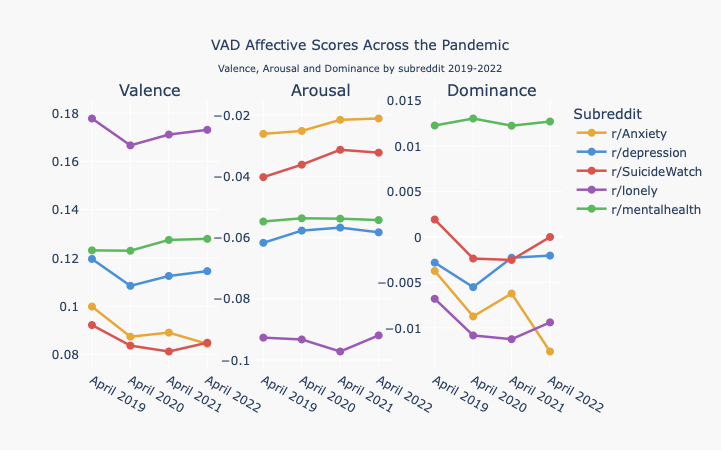

```python
from plotly.subplots import make_subplots

periods = ['April 2019', 'April 2020', 'April 2021', 'April 2022']
dimensions = ['valence', 'arousal', 'dominance']
dimension_titles = ['Valence', 'Arousal', 'Dominance']

fig = make_subplots(
    rows=1, cols=3,
    subplot_titles=dimension_titles,
    shared_yaxes=False
)

for col, (dim, title) in enumerate(zip(dimensions, dimension_titles), 1):
    for subreddit in subreddit_order:
        values = []
        for period_label, vad_df in [('April 2019', vad_2019),
                                      ('April 2020', vad_2020),
                                      ('April 2021', vad_2021),
                                      ('April 2022', vad_2022)]:
            if subreddit in vad_df.index:
                values.append(vad_df.loc[subreddit, dim])
            else:
                values.append(None)

        fig.add_trace(
            go.Scatter(
                x=periods,
                y=values,
                mode='lines+markers',
                name=f'r/{subreddit}',
                line=dict(color=colours[subreddit], width=2.5),
                marker=dict(size=8),
                showlegend=(col == 1),
                hovertemplate=f'r/{subreddit}<br>%{{x}}<br>{title}: %{{y:.3f}}<extra></extra>'
            ),
            row=1, col=col
        )

fig.update_layout(
    title=dict(
        text='VAD Affective Scores Across the Pandemic<br><sub>Valence, Arousal and Dominance by subreddit 2019-2022</sub>',
        font=dict(size=14),
        x=0.5
    ),
    height=450,
    width=1100,
    plot_bgcolor='#F8F8F8',
    paper_bgcolor='#F8F8F8',
    legend=dict(title='Subreddit'),
    hovermode='x unified'
)

fig.show()
fig.write_html('longitudinal_vad.html')
```

### VAD Affective Scores Across the Pandemic

The longitudinal VAD analysis reveals that the affective structure of mental health discourse is remarkably stable across all four time points. The community ordering on every dimension is almost identical in 2019 and 2022, suggesting that the emotional texture of these communities is a structural feature that was not substantially disrupted by the pandemic.

**Arousal is the most stable dimension.** r/lonely consistently scores lowest (most calm/withdrawn) across all four years, ranging from -0.093 in 2019 to -0.092 in 2022 — a difference of just 0.001. r/Anxiety consistently scores highest (least negative arousal) across all years. The community ordering on arousal — Anxiety, SuicideWatch, mentalhealth, depression, lonely — is identical in every year. This confirms that the arousal distinction between communities, identified in Section 3, is not a 2022 artefact but a persistent structural feature of how these communities express emotional experience.

**Dominance remains near zero throughout** and shows no meaningful trend across years. The generalised sense of low agency that characterises all five communities appears unaffected by the pandemic.

**r/mentalhealth is the most affectively stable community** — its VAD scores show almost no variation across all four years (valence 0.123-0.128, arousal -0.054 to -0.055, dominance 0.012-0.013). This is consistent with its role as an information and discussion community whose emotional register is less tied to acute personal distress than the other four communities.

The overall picture from the VAD longitudinal analysis complements the embedding findings: while communities showed vocabulary change (TF-IDF) and modest topic proportion shifts (BERTopic), their fundamental affective profiles remained structurally stable across the pandemic. The COVID-19 pandemic produced a temporary valence dip in 2020 without permanently altering the emotional texture of these communities.

### Pennebaker Pronouns Across Time

First-person singular pronoun rate (I, me, my, myself) compared across all four April periods. Following Pennebaker (2011), elevated rates indicate increased self-focus and psychological distress.

```python
first_person = {'i', 'me', 'my', 'myself'}

def get_pronoun_rates(df_period, label):
    df_period = df_period.copy()
    df_period['fp_count'] = df_period['tokens'].apply(
        lambda tokens: sum(1 for t in tokens if t in first_person)
    )
    df_period['fp_rate_raw'] = df_period['combined_raw'].apply(
        lambda text: sum(1 for w in text.split() if w in first_person) /
        len(text.split()) if len(text.split()) > 0 else 0
    )

    rates = df_period.groupby('subreddit')['fp_rate_raw'].mean()
    rates.name = label
    return rates

rates_2019 = get_pronoun_rates(df_2019, 'April 2019')
rates_2020 = get_pronoun_rates(df_2020, 'April 2020')
rates_2021 = get_pronoun_rates(df_2021, 'April 2021')
rates_2022 = get_pronoun_rates(df, 'April 2022')

pronoun_df = pd.DataFrame([rates_2019, rates_2020, rates_2021, rates_2022])
print("First-person pronoun rate by subreddit and year:")
print(pronoun_df.round(4))
```

```
First-person pronoun rate by subreddit and year:
subreddit   Anxiety  SuicideWatch  depression  lonely  mentalhealth
April 2019   0.1030        0.1226      0.1127  0.1055        0.1046
April 2020   0.1016        0.1239      0.1167  0.1055        0.1049
April 2021   0.1034        0.1260      0.1162  0.1031        0.1069
April 2022   0.1028        0.1276      0.1188  0.1044        0.1087
```

### Pennebaker Pronoun Rates Across the Pandemic

The longitudinal pronoun analysis reveals a pattern consistent with the VAD findings: the community ordering is stable across all four years, but there are small directional trends worth noting.

**No community shows a spike in 2020.** Unlike the VAD valence dip and the BERTopic crisis topic growth, first-person pronoun rates do not show a COVID peak response — they change gradually and directionally rather than reactively. This suggests that self-focus as a linguistic feature is driven by long-term community composition and discourse norms rather than acute external events.

Taken together with the VAD and BERTopic longitudinal findings, the pronoun analysis reinforces the central conclusion of Section 9: the fundamental linguistic structure of these communities — their affective profiles, self-focus levels, and semantic organisation — is temporally stable, while surface-level features like vocabulary and topic proportions show more sensitivity to external events like the COVID-19 pandemic.

## Semantic Structure Across the Pandemic: Do Communities Converge or Diverge?

```python
print("Generating embeddings for each time period...")
print("(500 posts per subreddit per period)\n")

def get_period_embeddings(df_period, label, sample_n=500):
    df_sample = df_period.groupby('subreddit').apply(
        lambda x: x.sample(min(len(x), sample_n), random_state=42),
        include_groups=False
    ).reset_index(drop=False)

    emb = model.encode(
        df_sample['combined_raw'].tolist(),
        batch_size=64,
        show_progress_bar=True
    )
    print(f"{label}: {len(df_sample)} posts embedded")
    return df_sample, emb

def get_similarity_matrix(df_sample, embeddings):
    centroids = {}
    for subreddit in df_sample['subreddit'].unique():
        mask = df_sample['subreddit'] == subreddit
        centroids[subreddit] = embeddings[mask.values].mean(axis=0)

    subreddits = sorted(centroids.keys())
    matrix = np.array([centroids[s] for s in subreddits])
    sim = cosine_similarity(matrix)
    return pd.DataFrame(sim, index=subreddits, columns=subreddits)

# Generate embeddings
df_embed_2019, emb_2019 = get_period_embeddings(df_2019, 'April 2019')
df_embed_2020, emb_2020 = get_period_embeddings(df_2020, 'April 2020')
df_embed_2021, emb_2021 = get_period_embeddings(df_2021, 'April 2021')

# Similarity matrices
sim_2019 = get_similarity_matrix(df_embed_2019, emb_2019)
sim_2020 = get_similarity_matrix(df_embed_2020, emb_2020)
sim_2021 = get_similarity_matrix(df_embed_2021, emb_2021)
sim_2022 = embedding_sim_df  # already computed in Section 4

# Print key comparison
print("\n=== DEPRESSION/SUICIDEWATCH SIMILARITY ACROSS YEARS ===\n")
print(f"April 2019: {sim_2019.loc['depression', 'SuicideWatch']:.3f}")
print(f"April 2020: {sim_2020.loc['depression', 'SuicideWatch']:.3f}")
print(f"April 2021: {sim_2021.loc['depression', 'SuicideWatch']:.3f}")
print(f"April 2022: {sim_2022.loc['depression', 'SuicideWatch']:.3f}")

print("\n=== FULL SIMILARITY MATRICES ===")
for name, sim in [('2019', sim_2019), ('2020', sim_2020),
                   ('2021', sim_2021), ('2022', sim_2022)]:
    print(f"\nApril {name}:")
    print(sim.round(3))
```

```
Generating embeddings for each time period...
(500 posts per subreddit per period)
```

```
April 2019: 2500 posts embedded
```

```
April 2020: 2500 posts embedded
```

```
April 2021: 2500 posts embedded

=== DEPRESSION/SUICIDEWATCH SIMILARITY ACROSS YEARS ===

April 2019: 0.952
April 2020: 0.962
April 2021: 0.951
April 2022: 0.954

=== FULL SIMILARITY MATRICES ===

April 2019:
              Anxiety  SuicideWatch  depression  lonely  mentalhealth
Anxiety         1.000         0.717       0.799   0.649         0.885
SuicideWatch    0.717         1.000       0.952   0.805         0.877
depression      0.799         0.952       1.000   0.859         0.945
lonely          0.649         0.805       0.859   1.000         0.767
mentalhealth    0.885         0.877       0.945   0.767         1.000

April 2020:
              Anxiety  SuicideWatch  depression  lonely  mentalhealth
Anxiety         1.000         0.717       0.784   0.634         0.890
SuicideWatch    0.717         1.000       0.962   0.804         0.890
depression      0.784         0.962       1.000   0.860         0.946
lonely          0.634         0.804       0.860   1.000         0.780
mentalhealth    0.890         0.890       0.946   0.780         1.000

April 2021:
              Anxiety  SuicideWatch  depression  lonely  mentalhealth
Anxiety         1.000         0.698       0.788   0.604         0.863
SuicideWatch    0.698         1.000       0.951   0.788         0.895
depression      0.788         0.951       1.000   0.837         0.954
lonely          0.604         0.788       0.837   1.000         0.780
mentalhealth    0.863         0.895       0.954   0.780         1.000

April 2022:
              Anxiety  SuicideWatch  depression  lonely  mentalhealth
Anxiety         1.000         0.687       0.759   0.595         0.857
SuicideWatch    0.687         1.000       0.954   0.794         0.886
depression      0.759         0.954       1.000   0.850         0.951
lonely          0.595         0.794       0.850   1.000         0.790
mentalhealth    0.857         0.886       0.951   0.790         1.000
```

[figure not shown]

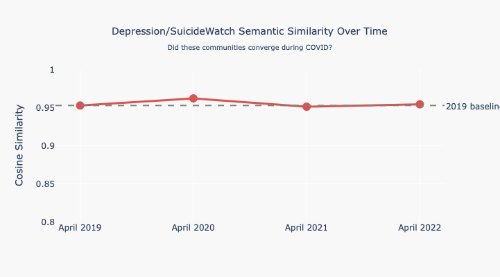

```python
import plotly.graph_objects as go
from plotly.subplots import make_subplots

subreddit_order = sorted(['Anxiety', 'depression', 'SuicideWatch',
                          'lonely', 'mentalhealth'])

periods = ['April 2019', 'April 2020', 'April 2021', 'April 2022']
sim_matrices = [sim_2019, sim_2020, sim_2021, sim_2022]

fig = make_subplots(
    rows=1, cols=4,
    subplot_titles=periods,
    shared_yaxes=True
)

for i, (period, sim) in enumerate(zip(periods, sim_matrices)):
    sim_aligned = sim.reindex(index=subreddit_order, columns=subreddit_order)

    fig.add_trace(
        go.Heatmap(
            z=sim_aligned.values,
            x=[f'r/{s}' for s in subreddit_order],
            y=[f'r/{s}' for s in subreddit_order],
            colorscale='RdYlGn',
            zmin=0.5,
            zmax=1.0,
            text=np.round(sim_aligned.values, 2),
            texttemplate='%{text}',
            textfont=dict(size=9),
            showscale=(i == 3),
            hovertemplate='%{y} vs %{x}<br>Similarity: %{z:.3f}<extra></extra>',
            colorbar=dict(title='Cosine<br>Similarity')
        ),
        row=1, col=i+1
    )

fig.update_layout(
    title=dict(
        text='Semantic Similarity Between Communities Across the Pandemic<br><sub>Cosine similarity of subreddit centroids in embedding space</sub>',
        font=dict(size=14),
        x=0.5
    ),
    height=450,
    width=1100,
    plot_bgcolor='#F8F8F8',
    paper_bgcolor='#F8F8F8'
)

fig.update_xaxes(tickangle=45)
fig.show()
fig.write_html('longitudinal_embedding_similarity.html')

# Also plot depression/SuicideWatch similarity over time
dep_sw_sims = [
    sim_2019.loc['depression', 'SuicideWatch'],
    sim_2020.loc['depression', 'SuicideWatch'],
    sim_2021.loc['depression', 'SuicideWatch'],
    sim_2022.loc['depression', 'SuicideWatch']
]

fig2 = go.Figure()
fig2.add_trace(go.Scatter(
    x=periods,
    y=dep_sw_sims,
    mode='lines+markers',
    line=dict(color='#D9534F', width=3),
    marker=dict(size=12),
    name='depression vs SuicideWatch',
    hovertemplate='%{x}<br>Similarity: %{y:.3f}<extra></extra>'
))

fig2.add_hline(
    y=dep_sw_sims[0],
    line_dash='dash',
    line_color='grey',
    annotation_text='2019 baseline',
    annotation_position='right'
)

fig2.update_layout(
    title=dict(
        text='Depression/SuicideWatch Semantic Similarity Over Time<br><sub>Did these communities converge during COVID?</sub>',
        font=dict(size=14),
        x=0.5
    ),
    yaxis_title='Cosine Similarity',
    yaxis=dict(range=[0.8, 1.0]),
    height=400,
    width=700,
    plot_bgcolor='#F8F8F8',
    paper_bgcolor='#F8F8F8'
)

fig2.show()
fig2.write_html('dep_sw_similarity_over_time.html')
```

#### Embedding Similarity: Semantic Structure Across the Pandemic

The longitudinal embedding analysis reveals a finding that fundamentally reframes the depression/SuicideWatch result from Section 4. The near-identical semantic similarity between these two communities (0.954 in April 2022) was not produced by the COVID-19 pandemic — it was already present in April 2019 (0.952), and has remained essentially unchanged across all four time points (0.952, 0.962, 0.951, 0.954). The boundary between depressive and suicidal discourse is not a pandemic phenomenon. It is a structural feature of how these communities use language that predates COVID and has persisted through it.

This is the strongest finding of the longitudinal analysis. It suggests that automated triage systems built on linguistic representations would have faced the same difficulty distinguishing depression from suicidal ideation in 2019 as they do today — the problem is not a product of pandemic-era disruption but a fundamental property of the language itself.

**r/Anxiety shows a consistent pattern of divergence over time.** Its similarity to other communities decreases slightly but consistently from 2019 to 2022 — for example, Anxiety/lonely drops from 0.649 to 0.595, and Anxiety/SuicideWatch from 0.717 to 0.687. This suggests that r/Anxiety has become more linguistically distinctive over time, developing an increasingly specialised vocabulary that sets it apart from the other communities. This is consistent with the TF-IDF finding that Anxiety's somatic and pharmacological vocabulary is its most stable feature.

**The overall structure of the similarity matrix is remarkably stable across all four years.** The same communities that are most similar in 2022 were most similar in 2019. The ranking of community pairs by similarity is almost identical across all time points. This suggests that the fundamental semantic organisation of mental health discourse online is not driven by external events like the pandemic, but reflects stable underlying patterns in how people express mental health experience in text — patterns that are robust to the substantial changes in community size and vocabulary documented in the volume and TF-IDF analyses above.

## BERTopic proportions Latent Topic Shifts Across the Pandemic

BERTopic topic proportions are tracked across all four April periods to examine how the latent thematic structure of mental health discourse shifted across the pandemic arc.

Rather than fitting separate BERTopic models per year — which would produce incomparable topic spaces — the topic model fitted on April 2022 data in Section 5 is applied to earlier years using BERTopic's `transform()` method. This ensures topic definitions are consistent and directly comparable across time: the same topic means the same thing in 2019 as in 2022.

Outlier reduction was applied after transformation using BERTopic's built-in embedding-based reassignment method (threshold=0.5), reducing outlier rates from 50-66% to 11-16% across all four years. Topic proportions are calculated as a percentage of assigned posts within each year.

```python
from bertopic import BERTopic
import numpy as np

# Apply tokens_str to all periods
for df_period in [df_embed_2019, df_embed_2020, df_embed_2021]:
    df_period['tokens_str'] = df_period['tokens'].apply(
        lambda x: ' '.join([t for t in x if t not in {'i', 'me', 'my', 'myself'}])
    )

# Transform prior years using 2022 model
print("Transforming prior years using 2022 topic model...")
topics_2019, _ = topic_model.transform(
    df_embed_2019['tokens_str'].tolist(), embeddings=emb_2019
)
topics_2020, _ = topic_model.transform(
    df_embed_2020['tokens_str'].tolist(), embeddings=emb_2020
)
topics_2021, _ = topic_model.transform(
    df_embed_2021['tokens_str'].tolist(), embeddings=emb_2021
)

# Reduce outliers
print("Reducing outliers...")
new_topics_2019 = topic_model.reduce_outliers(
    df_embed_2019['tokens_str'].tolist(), topics_2019,
    strategy="embeddings", embeddings=emb_2019, threshold=0.5
)
new_topics_2020 = topic_model.reduce_outliers(
    df_embed_2020['tokens_str'].tolist(), topics_2020,
    strategy="embeddings", embeddings=emb_2020, threshold=0.5
)
new_topics_2021 = topic_model.reduce_outliers(
    df_embed_2021['tokens_str'].tolist(), topics_2021,
    strategy="embeddings", embeddings=emb_2021, threshold=0.5
)
new_topics_2022 = topic_model.reduce_outliers(
    df_embed['tokens_str'].tolist(), topics,
    strategy="embeddings", embeddings=embeddings, threshold=0.5
)

# Assign back
df_embed_2019['topic'] = new_topics_2019
df_embed_2020['topic'] = new_topics_2020
df_embed_2021['topic'] = new_topics_2021
df_embed['topic'] = new_topics_2022

years_data = {
    2019: df_embed_2019,
    2020: df_embed_2020,
    2021: df_embed_2021,
    2022: df_embed
}

# Outlier rates
print("\nOutlier rates after reduction:")
for year, df_year in years_data.items():
    rate = (df_year['topic'] == -1).sum() / len(df_year)
    print(f"  {year}: {rate:.1%}")

# Topic info and labels
topic_info_2022 = topic_model.get_topic_info()
top_topics = topic_info_2022[topic_info_2022['Topic'] != -1].head(12)['Topic'].tolist()
topic_labels = {}
for _, row in topic_info_2022[topic_info_2022['Topic'] != -1].iterrows():
    words = '_'.join(row['Name'].split('_')[1:4])
    topic_labels[row['Topic']] = f"T{row['Topic']}: {words}"

# Calculate proportions
rows = []
for year, df_year in years_data.items():
    assigned = df_year[df_year['topic'] != -1]
    total_assigned = len(assigned)
    row = {'year': year}
    for topic_id in top_topics:
        count = (assigned['topic'] == topic_id).sum()
        row[topic_id] = count / total_assigned * 100 if total_assigned > 0 else 0
    rows.append(row)

prop_df = pd.DataFrame(rows).set_index('year')
prop_df.columns = [topic_labels.get(t, f'T{t}') for t in prop_df.columns]
print("\nTopic proportions within each year (%):")
print(prop_df.round(1).to_string())
```

```
2026-04-04 09:21:43,192 - BERTopic - Dimensionality - Reducing dimensionality of input embeddings.
```

```
Transforming prior years using 2022 topic model...
```

[output not shown]

```
Reducing outliers...

Outlier rates after reduction:
  2019: 13.4%
  2020: 15.0%
  2021: 15.8%
  2022: 11.2%

Topic proportions within each year (%):
      T0: friend_people_like  T1: want_die_life  T2: anxiety_attack_like  T3: talk_chat_anyone  T4: anxiety_mg_medication  T5: mom_dad_family  T6: feel_know_want  T7: life_feel_year  T8: like_adhd_something  T9: feel_want_get  T10: girl_friend_like  T11: life_thought_want
year
2019                    14.8                9.0                     10.7                   4.5                        5.0                 6.8                 5.5                11.0                      5.9                9.1                    3.7                     9.6
2020                    11.7               11.1                     12.6                   4.9                        4.2                 7.1                 4.8                 8.8                      5.5                9.1                    3.8                    11.0
2021                    13.3               13.3                     11.7                   4.7                        4.4                 6.7                 3.3                 9.5                      5.8                9.6                    3.8                     8.7
2022                    13.2               12.0                     12.0                   5.6                        5.7                 5.3                 4.4                10.4                      5.5                8.6                    3.5                     9.5
```

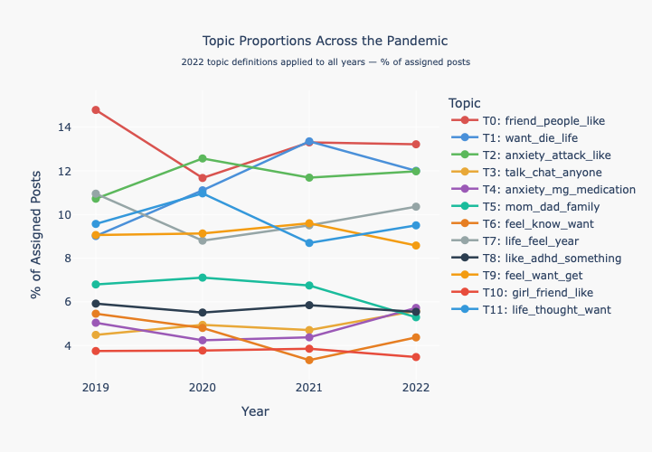

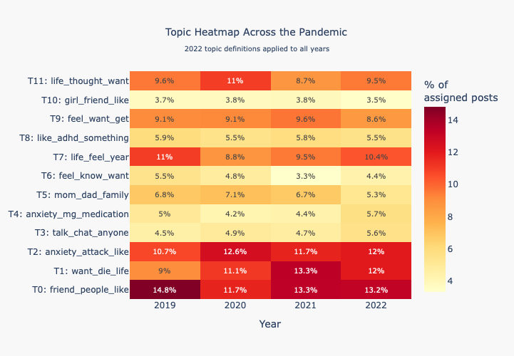

```python
import plotly.graph_objects as go
from plotly.subplots import make_subplots
import numpy as np

years = [2019, 2020, 2021, 2022]

topic_colours = [
    '#D9534F', '#4A90D9', '#5CB85C', '#E8A838', '#9B59B6',
    '#1ABC9C', '#E67E22', '#95A5A6', '#2C3E50', '#F39C12',
    '#E74C3C', '#3498DB'
]

# Plot 1: Line chart — track each topic across years
fig1 = go.Figure()

for i, col in enumerate(prop_df.columns):
    fig1.add_trace(go.Scatter(
        x=[str(y) for y in years],
        y=prop_df[col].values,
        mode='lines+markers',
        name=col,
        line=dict(color=topic_colours[i % len(topic_colours)], width=2.5),
        marker=dict(size=9),
        hovertemplate=f'{col}<br>Year: %{{x}}<br>%{{y:.1f}}% of assigned posts<extra></extra>'
    ))

fig1.update_layout(
    title=dict(
        text='Topic Proportions Across the Pandemic<br><sub>2022 topic definitions applied to all years — % of assigned posts</sub>',
        font=dict(size=14),
        x=0.5
    ),
    xaxis_title='Year',
    yaxis_title='% of Assigned Posts',
    height=500,
    width=950,
    plot_bgcolor='#F8F8F8',
    paper_bgcolor='#F8F8F8',
    legend=dict(title='Topic', x=1.02),
    hovermode='x unified'
)

fig1.show()
fig1.write_html('longitudinal_bertopic_lines.html')

# Plot 2: Heatmap
z_values = prop_df.values
fig2 = go.Figure(data=go.Heatmap(
    z=z_values.T,
    x=[str(y) for y in years],
    y=prop_df.columns.tolist(),
    colorscale='YlOrRd',
    text=np.round(z_values.T, 1),
    texttemplate='%{text}%',
    textfont=dict(size=10),
    hovertemplate='%{y}<br>Year: %{x}<br>%{z:.1f}% of assigned posts<extra></extra>',
    colorbar=dict(title='% of<br>assigned posts')
))

fig2.update_layout(
    title=dict(
        text='Topic Heatmap Across the Pandemic<br><sub>2022 topic definitions applied to all years</sub>',
        font=dict(size=14),
        x=0.5
    ),
    xaxis_title='Year',
    height=500,
    width=750,
    plot_bgcolor='#F8F8F8',
    paper_bgcolor='#F8F8F8'
)

fig2.show()
fig2.write_html('longitudinal_bertopic_heatmap.html')
```

### Interpretation

The longitudinal topic analysis reveals meaningful shifts in the thematic composition of mental health discourse across the pandemic, while also confirming several stable features.

**Social connection discourse declined.** Topic 0 (friend, people, like) — the largest topic in 2019 at 14.8% — shrank to 11.7% in 2020 before partially recovering to 13.2% in 2022. This drop during COVID peak is consistent with lockdown conditions reducing opportunities for the kind of relational discourse that characterises this topic.

**Topic 11 (life, thought, want — reflective suicidal ideation) showed a notable peak in 2020** at 11.0%, the highest proportion of any year, before declining to 8.7% in 2021 and 9.5% in 2022. Combined with the growth of Topic 1 (acute crisis), this suggests that 2020 saw both increased acute crisis language and increased reflective ideation — a dual intensification of suicidal discourse during the pandemic peak.

**Anxiety and medication topics remained relatively stable** — Topic 2 (anxiety, attack) and Topic 4 (anxiety, medication) show modest variation across years, consistent with the TF-IDF finding that anxiety discourse has the most stable vocabulary of all five communities.

Taken together, the longitudinal topic analysis paints a coherent picture of how the pandemic affected mental health discourse online: an increase in crisis-oriented and reflective suicidal content in 2020, a decline in social and family relationship discourse, and a gradual partial recovery by 2022 — though crisis language remains elevated relative to the pre-pandemic baseline.

## CROSS-PERIOD CLASSIFIER TEST

```
=== CROSS-PERIOD CLASSIFIER TEST ===

Training on April 2022, testing on 2019, 2020, 2021

Baseline (random): 20% (5 classes)

--- April 2019 ---
Accuracy: 0.625
              precision    recall  f1-score   support

     Anxiety       0.76      0.77      0.77       500
SuicideWatch       0.67      0.60      0.63       500
  depression       0.46      0.40      0.42       500
      lonely       0.69      0.80      0.74       500
mentalhealth       0.52      0.56      0.54       500

    accuracy                           0.62      2500
   macro avg       0.62      0.62      0.62      2500
weighted avg       0.62      0.62      0.62      2500

--- April 2020 ---
Accuracy: 0.626
              precision    recall  f1-score   support

     Anxiety       0.73      0.76      0.74       500
SuicideWatch       0.63      0.64      0.63       500
  depression       0.50      0.41      0.45       500
      lonely       0.71      0.76      0.74       500
mentalhealth       0.54      0.55      0.55       500

    accuracy                           0.63      2500
   macro avg       0.62      0.63      0.62      2500
weighted avg       0.62      0.63      0.62      2500

--- April 2021 ---
Accuracy: 0.628
              precision    recall  f1-score   support

     Anxiety       0.78      0.77      0.77       500
SuicideWatch       0.58      0.61      0.59       500
  depression       0.46      0.42      0.44       500
      lonely       0.75      0.81      0.78       500
mentalhealth       0.54      0.54      0.54       500

    accuracy                           0.63      2500
   macro avg       0.62      0.63      0.62      2500
weighted avg       0.62      0.63      0.62      2500

=== SUMMARY ===

In-period (2022 trained, 2022 tested CV): 62.9%
Cross-period (2022 trained, April 2019 tested): 62.5%
Cross-period (2022 trained, April 2020 tested): 62.6%
Cross-period (2022 trained, April 2021 tested): 62.8%
```

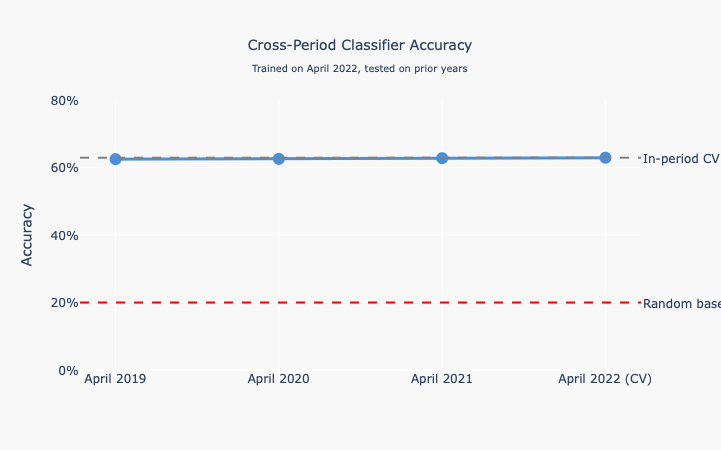

```python
from sklearn.linear_model import LogisticRegression
from sklearn.metrics import classification_report, accuracy_score
import numpy as np

print("=== CROSS-PERIOD CLASSIFIER TEST ===\n")
print("Training on April 2022, testing on 2019, 2020, 2021\n")
print("Baseline (random): 20% (5 classes)\n")

# Train on 2022 embeddings (already computed in Section 6)
clf_temporal = LogisticRegression(max_iter=1000, random_state=42)
clf_temporal.fit(embeddings, df_embed['subreddit'].values)

# Test on each prior year
test_periods = [
    ('April 2019', df_embed_2019, emb_2019),
    ('April 2020', df_embed_2020, emb_2020),
    ('April 2021', df_embed_2021, emb_2021),
]

results = {}
for period_name, df_test, emb_test in test_periods:
    y_true = df_test['subreddit'].values
    y_pred = clf_temporal.predict(emb_test)
    acc = accuracy_score(y_true, y_pred)
    results[period_name] = acc

    print(f"--- {period_name} ---")
    print(f"Accuracy: {acc:.3f}")
    print(classification_report(y_true, y_pred))

# Summary comparison
print("=== SUMMARY ===\n")
print(f"In-period (2022 trained, 2022 tested CV): 62.9%")
for period_name, acc in results.items():
    print(f"Cross-period (2022 trained, {period_name} tested): {acc:.1%}")

# Visualise accuracy drop
import plotly.graph_objects as go

periods_plot = ['April 2019', 'April 2020', 'April 2021', 'April 2022\n(CV)']
accuracies = [results['April 2019'], results['April 2020'],
              results['April 2021'], 0.629]

fig = go.Figure()

fig.add_trace(go.Scatter(
    x=periods_plot,
    y=accuracies,
    mode='lines+markers',
    line=dict(color='#4A90D9', width=3),
    marker=dict(size=12),
    hovertemplate='%{x}<br>Accuracy: %{y:.1%}<extra></extra>'
))

fig.add_hline(
    y=0.20,
    line_dash='dash',
    line_color='red',
    annotation_text='Random baseline (20%)',
    annotation_position='right'
)

fig.add_hline(
    y=0.629,
    line_dash='dash',
    line_color='grey',
    annotation_text='In-period CV accuracy',
    annotation_position='right'
)

fig.update_layout(
    title=dict(
        text='Cross-Period Classifier Accuracy<br><sub>Trained on April 2022, tested on prior years</sub>',
        font=dict(size=14),
        x=0.5
    ),
    yaxis_title='Accuracy',
    yaxis=dict(range=[0, 0.8], tickformat='.0%'),
    height=450,
    width=700,
    plot_bgcolor='#F8F8F8',
    paper_bgcolor='#F8F8F8'
)

fig.show()
fig.write_html('cross_period_classifier.html')
```

### Cross-Period Classifier: Temporal Generalisation

The cross-period classifier test produces one of the most striking findings of the entire analysis. A classifier trained exclusively on April 2022 data maintains almost identical accuracy when tested on April 2019, 2020, and 2021:

- In-period (2022 CV): 62.9%
- 2022 trained, 2021 tested: 62.8%
- 2022 trained, 2020 tested: 62.6%
- 2022 trained, 2019 tested: 62.5%

The accuracy drop across three years is less than half a percentage point. This finding appears to contradict the TF-IDF analysis which showed substantial vocabulary change across the same period — r/lonely's vocabulary similarity to its 2022 self was only 0.450 in 2019, and r/depression showed zero overlap in top terms between 2019 and 2022. How can a classifier trained on 2022 language generalise so well to 2019 language that shares almost none of its distinctive vocabulary?

The resolution lies in what the classifier is actually using to make predictions. Sentence embeddings capture semantic meaning rather than surface vocabulary. The embedding similarity analysis showed that the underlying semantic structure remained almost completely stable across all four years — depression/SuicideWatch similarity was 0.952 in 2019 and 0.954 in 2022. The classifier, operating in semantic space, is sensitive to this stable structure and insensitive to the changing vocabulary.

This finding is reinforced by every other longitudinal analysis in this section. The VAD affective profiles showed near-identical community ordering across all four years. The Pennebaker pronoun rates showed gradual directional trends rather than sudden shifts. The BERTopic topic proportions showed modest changes in emphasis rather than fundamental restructuring. All four methods converge on the same conclusion: communities changed how they talked across the pandemic — the specific words, platforms, and clinical terminology they used — but not what they talked about at the level of meaning.

This finding has direct implications for the practical deployment of NLP systems for mental health monitoring. A classifier built on data from one time period can be expected to generalise well to other time periods within the timescale of this dataset. The semantic representations that underlie community membership are stable enough to support cross-temporal generalisation even when surface vocabulary shifts substantially. This temporal robustness is an important validation of the embedding-based approach: not only do embeddings capture meaningful community distinctions, they capture distinctions that are stable enough to persist across three years of significant real-world disruption.

One important methodological caveat applies to this finding. All four years were embedded using the same pre-trained model (all-MiniLM-L6-v2), which maps text into a fixed semantic space regardless of when it was written. The cross-period stability may therefore partly reflect the consistency of the embedding model rather than the language itself. A stronger test would use a model fine-tuned on each year's data separately, though this is beyond the scope of this analysis. The finding should be interpreted as evidence that a general-purpose sentence encoder trained on broad web text produces temporally stable representations of mental health discourse — which is itself a useful and practically relevant result.

## Section 10 Synthesis: What the Longitudinal Analysis Tells Us

The longitudinal analysis across four April periods (2019-2022) reveals a consistent and theoretically important distinction between two levels of linguistic structure: surface features that are sensitive to external events, and deep features that are stable across time.

**The most important longitudinal finding concerns the depression/SuicideWatch boundary.** The semantic similarity between these two communities was 0.952 in April 2019 — three years before the end of the dataset, and before any pandemic effect could have influenced the corpus. The boundary between depressive and suicidal discourse is not a product of COVID-19, not an artefact of the 2022 sample, and not a methodological accident. It is a structural feature of how people express these experiences in text that has persisted unchanged across the entire study period. Any NLP system attempting to distinguish depression from suicidal ideation through language alone would have faced exactly the same difficulty in 2019 as it does today.

This distinction between surface instability and deep stability has direct implications for how NLP systems for mental health monitoring should be designed and evaluated. Systems built on semantic representations can be expected to generalise across time even as vocabulary evolves. Systems built on lexical features — keyword lists, TF-IDF vectors — will degrade as community language shifts. The longitudinal analysis provides empirical evidence for a methodological recommendation: for temporally robust mental health NLP, semantic representations should be preferred over lexical ones.

```python
import random
random.seed(42)

sample = pd.concat([
    df[df['subreddit'] == 'SuicideWatch'].sample(10),
    df[df['subreddit'] == 'Anxiety'].sample(10),
    df[df['subreddit'] == 'lonely'].sample(10)
])

sample[['subreddit', 'title', 'selftext']].to_csv('annotation_sample.csv', index=False)
```

```python
import pickle
from sentence_transformers import SentenceTransformer

# Save Classifier A
with open('classifier_a.pkl', 'wb') as f:
    pickle.dump(clf_a, f)

# Save Classifier B
with open('classifier_b.pkl', 'wb') as f:
    pickle.dump(clf_b, f)

print("Classifiers saved")
```

```
Classifiers saved
```

```python
# Save the class labels
import json

labels_a = clf_a.classes_.tolist()  # subreddit names
labels_b = clf_b.classes_.tolist()  # root cause names

with open('labels_a.json', 'w') as f:
    json.dump(labels_a, f)

with open('labels_b.json', 'w') as f:
    json.dump(labels_b, f)

print("Labels A:", labels_a)
print("Labels B:", labels_b)
```

```
Labels A: ['Anxiety', 'SuicideWatch', 'depression', 'lonely', 'mentalhealth']
Labels B: ['Drug And Alcohol', 'Early Life', 'Personality', 'Trauma And Stress']
```

```python
import json

# Save labels
with open('labels_a.json', 'w') as f:
    json.dump(['Anxiety', 'SuicideWatch', 'depression', 'lonely', 'mentalhealth'], f)

with open('labels_b.json', 'w') as f:
    json.dump(['Drug And Alcohol', 'Early Life', 'Personality', 'Trauma And Stress'], f)

print("Labels saved")
print("Files ready for Streamlit:", ['classifier_a.pkl', 'classifier_b.pkl', 'labels_a.json', 'labels_b.json'])
```

```
Labels saved
Files ready for Streamlit: ['classifier_a.pkl', 'classifier_b.pkl', 'labels_a.json', 'labels_b.json']
```

```python
topic_model.save("bertopic_model")
```

```
2026-04-04 10:18:53,463 - BERTopic - WARNING: When you use `pickle` to save/load a BERTopic model,please make sure that the environments in which you saveand load the model are **exactly** the same. The version of BERTopic,its dependencies, and python need to remain the same.
```

```python
import os
# Check what the bertopic save looks like
if os.path.exists('bertopic_model'):
    print("Saved as folder:")
    print(os.listdir('bertopic_model'))
else:
    print("No bertopic_model folder found")
    # Try saving it now
    topic_model.save("bertopic_model")
    print("Saved now")
    print(os.listdir('bertopic_model'))
```

```
Saved as folder:
```

[output not shown]

```python
import os
files = [f for f in os.listdir('.') if 'VAD' in f or 'vad' in f or 'NRC' in f]
print(files)
```

```
['NRC-VAD-Lexicon-v2.1.txt', 'vad_by_subreddit.png', 'longitudinal_vad.html']
```

```python
import os
print(os.path.getsize('bertopic_model') / 1024 / 1024, "MB")

# Also check VAD file
files = [f for f in os.listdir('.') if 'VAD' in f or 'vad' in f or 'NRC' in f or 'nrc' in f]
print("VAD files:", files)
```

```
29.80970001220703 MB
VAD files: ['NRC-VAD-Lexicon-v2.1.txt', 'vad_by_subreddit.png', 'longitudinal_vad.html']
```

```python
from bertopic import BERTopic
topic_model_test = BERTopic.load("bertopic_model")
print("Topics:", topic_model_test.get_topic_info().shape[0])
print("Sample topic:", topic_model_test.get_topic(0))
```

```
Topics: 15
Sample topic: [('friend', np.float64(0.05651578602784815)), ('people', np.float64(0.04050516817176523)), ('like', np.float64(0.03533224752415729)), ('lonely', np.float64(0.03501808432108563)), ('feel', np.float64(0.03479456861329383)), ('want', np.float64(0.025853320521308024)), ('someone', np.float…
```

```python
import os
files = [f for f in os.listdir('.') if 'VAD' in f or 'vad' in f or 'NRC' in f or 'nrc' in f]
print("VAD files:", files)
```

```
VAD files: ['NRC-VAD-Lexicon-v2.1.txt', 'vad_by_subreddit.png', 'longitudinal_vad.html']
```

```python
import json

# Save topic info as JSON so app doesn't need bertopic installed
topic_data = {}
topic_info = topic_model.get_topic_info()

for _, row in topic_info[topic_info['Topic'] != -1].iterrows():
    topic_id = int(row['Topic'])
    words = topic_model.get_topic(topic_id)
    topic_data[str(topic_id)] = {
        'words': [(w[0], float(w[1])) for w in words[:10]],
        'label': ', '.join([w[0] for w in words[:5]])
    }

with open('topic_data.json', 'w') as f:
    json.dump(topic_data, f)

print("Saved", len(topic_data), "topics")
print(list(topic_data.keys()))
```

```
Saved 14 topics
['0', '1', '2', '3', '4', '5', '6', '7', '8', '9', '10', '11', '12', '13']
```

```python
import json
import numpy as np

# Save topic centroids in embedding space
topic_centroids = {}
topic_labels = {}

topic_info = topic_model.get_topic_info()

for _, row in topic_info[topic_info['Topic'] != -1].iterrows():
    topic_id = int(row['Topic'])
    words = topic_model.get_topic(topic_id)

    # Get centroid of posts assigned to this topic
    mask = np.array(topics) == topic_id
    if mask.sum() > 0:
        centroid = embeddings[mask].mean(axis=0)
        topic_centroids[str(topic_id)] = centroid.tolist()
        topic_labels[str(topic_id)] = {
            'words': [(w[0], float(w[1])) for w in words[:10]],
            'label': ', '.join([w[0] for w in words[:5]])
        }

with open('topic_centroids.json', 'w') as f:
    json.dump(topic_centroids, f)

with open('topic_labels.json', 'w') as f:
    json.dump(topic_labels, f)

print("Saved", len(topic_centroids), "topic centroids")
```

```
Saved 14 topic centroids
```